# PRECIS-2 Scores in PragMeta: Human Consensus vs LMM (Claude 2)

### Score comparisons of 56 publications

| Ref. | Author & Year | weighted κ | agreement | pooled weighted κ | pooled agreement |
| --- | --- | --- | --- | --- | --- |
| 648 | CORONIS Collaborative Group (2013) | 0.333333333333333 | 0.444444444444444 | 0.294117647058823 | 0.555555555555556 |
| 650 | van Dijk-de Vries. A, (2015) | 0.375 | 0.333333333333333 | 0.25 | 0.444444444444444 |
| 651 | Price. D, (2011) | -2.22044604925031e-16 | 0.444444444444444 | 0 | 0.888888888888889 |
| 655 | Galdiz, J. B. (2020) | 0.0904255319148934 | 0.222222222222222 | -0.166666666666667 | 0.222222222222222 |
| 657 | Arntzen E. (2019) | 0.341463414634146 | 0.333333333333333 | 0.181818181818182 | 0.555555555555556 |
| 662 | Bogosian A. (2015) | 0.0604395604395603 | 0.222222222222222 | -0.102040816326531 | 0.333333333333333 |
| 663 | Callesen J. (2020) | -0.182481751824818 | 0.333333333333333 | -0.18421052631579 | 0.444444444444444 |
| 664 | Carter A. (2014) | -0.444444444444444 | 0.222222222222222 | -0.285714285714286 | 0.555555555555556 |
| 665 | Cooper C. (2011) | 0.0869565217391304 | 0.111111111111111 | 0 | 0.444444444444444 |
| 666 | Cutter G. (2019) | 0.329787234042553 | 0.444444444444444 | 0.307692307692308 | 0.555555555555556 |

[output cut: 46 more lines]

### Score heatmaps (unpooled / pooled)

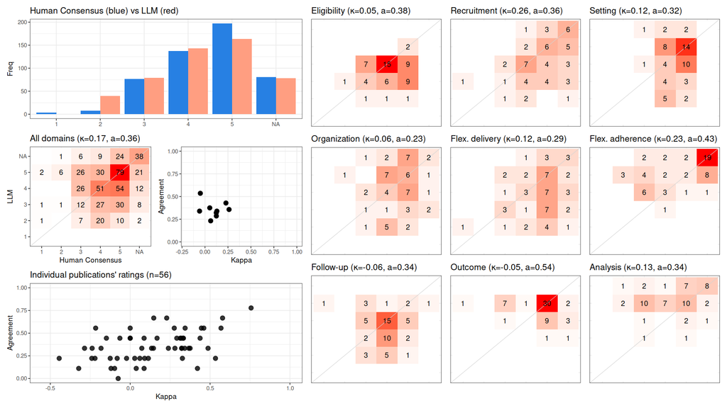

### Individual results

#### 648. CORONIS Collaborative Group (2013): *Caesarean section surgical techniques (CORONIS): a fractional, factorial, unmasked, randomised controlled trial*

PRECIS-2

|  | D1 | D2 | D3 | D4 | D5 | D6 | D7 | D8 | D9 |
| --- | --- | --- | --- | --- | --- | --- | --- | --- | --- |
| Human Consensus | 4 | NA | 5 | 5 | 3 | NA | 5 | 3 | 3 |
| LLM | 4 | NA | 5 | NA | 5 | NA | 4 | 4 | 5 |

LLM response

*7 quote(s) from publication full text (mean similarity 99.9%)*

```
Here are the PRECIS-2 scores I would give for the CORONIS trial based on the attached publication:

Eligibility criteria
Relevant quotes:
"Pregnant women were eligible if they were to undergo delivery by lower segment caesarean section through a transverse abdominal incision, irrespective of fever in labour, gestational age, or multiple pregnancies."
"Women were not eligible if there was a clear indication for a particular surgical technique or material to be used that prevented any of the allocated interventions being used, if they had more than one previous caesarean section, or if they had already been recruited into the trial."

Reasoning: The eligibility criteria are quite broad, including women undergoing both elective and emergency cesarean section, at any gestational age, and with singleton or multiple pregnancies. The only notable exclusions are women with more than one previous cesarean section and those with a clear …

Score: [4] Rather pragmatic

Recruitment
Relevant quotes: No details provided on recruitment process.

Reasoning: Since no information is provided on how participants were recruited, I cannot assess this domain.

Score: [NA]

Setting
Relevant quotes:
"CORONIS was undertaken at 19 sites in Argentina, Chile, Ghana, India, Kenya, Pakistan, and Sudan."

Reasoning: The trial was conducted across multiple sites in 7 countries across 3 continents. This indicates that the setting is intended to be generalizable and applicable across diverse geographic regions and healthcare systems.

Score: [5] Very pragmatic

Organization
Relevant quotes: No details provided on organization of care delivery.

Reasoning: No information is provided on the expertise of care providers or resources available, so I cannot assess whether the organization differed from usual care.

Score: [NA]

Flexibility: Delivery
Relevant quotes: No quotes, but the Methods section states "All non-allocated surgical elements and all other aspects of the caesarean section procedure were undertaken at the discretion of the surgeon."

Reasoning: Letting surgeons use their own discretion in how to deliver the allocated interventions suggests a very flexible approach that should mirror usual care.

Score: [5] Very pragmatic

```

[output cut: 15 more lines]

```
Primary outcome
Relevant quotes:
"The primary outcome was a composite of death, maternal infectious morbidity, further operative procedures, or blood transfusion (>1 unit) up to the 6-week follow-up visit."

Reasoning: The components of the primary composite outcome are clinically important events that would be meaningful to patients and providers. The 6-week time period also seems reasonable and relevant.

Score: [4] Rather pragmatic

Primary analysis
Relevant quotes:
"Women were analysed in the groups into which they were allocated."

Reasoning: Analyzing participants according to the group they were randomized to, regardless of adherence, represents an intention-to-treat approach that is very pragmatic.

Score: [5] Very pragmatic
```

#### 650. [van Dijk-de Vries. A, (2015): *Lessons learnt from a cluster-randomised trial evaluating the effectiveness of Self-Management Support (SMS) delivered by practice nurses in routine diabetes care*](https://doi.org/10.1136/bmjopen-2014-007014)

PRECIS-2

|  | D1 | D2 | D3 | D4 | D5 | D6 | D7 | D8 | D9 |
| --- | --- | --- | --- | --- | --- | --- | --- | --- | --- |
| Human Consensus | 3 | 4 | 5 | 4 | 5 | NA | 4 | 5 | 3 |
| LLM | 2 | 2 | 3 | 4 | 3 | NA | 3 | 4 | 3 |

LLM response

*18 quote(s) from publication full text (mean similarity 99.3%)*

```
Here are the PRECIS-2 scores and explanations for the trial described in "650.pdf":

Eligibility criteria:

Relevant quotes:

"Patients with a clinically established diagnosis of type 2 diabetes mellitus were sent a letter by their GPs to introduce the SMS project."

"The enclosed self-administered questionnaire consisted of the screening instruments that intervention PNs would also apply for SMS in their routine practice. It included the ‘Daily Functioning Thermometer’ (DFT), which is a Visual Analogue Scale to measure how suffering under the burden of diabetes…

"From all 1805 patients who participated in the screening, 357 (20%) met the detection criteria and were invited to take part in the trial."

Explanation: The eligibility criteria for the trial participants were based on a screening questionnaire that was not part of routine care. The screening instruments were intended to select patients with emotional distress and reduced daily functioning, but were not used in usual care. This makes th…

Score: [2]

Recruitment:

Relevant quotes:

"Patients with a clinically established diagnosis of type 2 diabetes mellitus were sent a letter by their GPs to introduce the SMS project."

"The enclosed self-administered questionnaire consisted of the screening instruments that intervention PNs would also apply for SMS in their routine practice."

"From all 1805 patients who participated in the screening, 357 (20%) met the detection criteria and were invited to take part in the trial."

Explanation: Patients were recruited by sending screening questionnaires to identify eligible patients. This required additional efforts beyond what would occur in routine care. Recruitment was done prior to clinic visits rather than recruiting patients who presented in clinic. This makes the recrui…

Score: [2]

Setting:

Relevant quotes:

"The study was conducted between November 2011 and February 2013 and was registered in a Dutch public trial registry [NTR2764]. The study protocol has been published elsewhere."

"All the family practices of one regional organisation of GPs (a so-called ‘care group’) in the South of the Netherlands were eligible to participate in the study."

Explanation: The trial was conducted in family practice settings, which matches the intended setting for the intervention's use in routine care. However, it was limited to a single regional care group, reducing generalizability. Overall this makes the setting moderately pragmatic.

```

[output cut: 56 more lines]

```
Explanation: The primary outcome directly measures the patient's perceived daily functioning, which is relevant and important to patients. This makes it pragmatic.

Score: [4]

Primary analysis:

Relevant quotes:

"Analyses were performed on an intention-to-treat basis."

"Only 16 of the 117 patients in the intervention arm (14%) who were found eligible by the posted research-driven screening questionnaire were detected by their practice nurses."

Explanation: The analysis was done on an intention-to-treat basis, which is pragmatic. However, the low exposure to the actual intervention for many patients in the intervention arm reduces pragmatism. Overall this makes the analysis moderately pragmatic.

Score: [3]
```

#### 651. [Price. D, (2011): *Leukotriene antagonists as first-line or add-on asthma-controller therapy*](https://doi.org/10.1056/NEJMoa1010846)

PRECIS-2

|  | D1 | D2 | D3 | D4 | D5 | D6 | D7 | D8 | D9 |
| --- | --- | --- | --- | --- | --- | --- | --- | --- | --- |
| Human Consensus | 5 | 5 | 5 | NA | 4 | 4 | 4 | 5 | 4 |
| LLM | 4 | 5 | 5 | 5 | 5 | 5 | 4 | 5 | 5 |

LLM response

*12 quote(s) from publication full text (mean similarity 100%)*

```
Here are the PRECIS-2 scores for the trial based on the full text publication:

Eligibility criteria

Quotes:
"Eligible primary care patients 12 to 80 years of age had impaired asthma-related quality of life (Mini Asthma Quality of Life Questionnaire [MiniAQLQ] score ≤6) or inadequate asthma control (Asthma Control Questionnaire [ACQ] score ≥1)."

"Main exclusion criteria were prior treatment within 12 weeks with an inhaled glucocorticoid or LTRA (in the first-line controller therapy trial) or LTRA or LABA (in the add-on therapy trial)."

Reasoning: The trial included a broad range of primary care asthma patients based on symptom criteria, without extensive diagnostic testing. The main exclusions were prior use of the study medications. This matches usual care eligibility.

Score: [4] Rather pragmatic

Recruitment

Quotes:
"Patients who met the eligibility criteria completed a validated asthma-symptom diary for 2 weeks before the baseline visit for an assessment of PEF variability and to record current symptoms."

"In the first-line controller therapy trial, eligible patients had asthma symptoms deemed by their physician to require initiation of asthma-controller therapy."

Reasoning: Patients were recruited when they presented to their primary care physician with asthma symptoms requiring treatment. This matches usual care.

Score: [5] Very pragmatic

Setting

Quotes:
"The two trials, which were conducted at 53 primary care practices in the United Kingdom, enrolled patients 12 to 80 years of age with a physician’s diagnosis of asthma."

Reasoning: The trial was conducted in multiple primary care practices, the typical setting for asthma management.

Score: [5] Very pragmatic

Organisation

Quotes:
"Practice staffs were asked to provide each patient with a written individualized asthma-action plan. For each of the assigned treatments, choices of individual drugs and devices were made according to normal clinical practice and British asthma guidelines."

Reasoning: Usual primary care staff and resources were used to deliver the interventions according to normal practice.

```

[output cut: 33 more lines]

```
Quotes:
"The primary outcome measure was the MiniAQLQ score."

Reasoning: The MiniAQLQ measures asthma quality of life, a patient-centered outcome.

Score: [5] Very pragmatic

Primary analysis

Quotes:
"The primary effectiveness analysis was an intention-to-treat analysis of the MiniAQLQ score at 2 months (the primary time point) and at 2 years."

Reasoning: The primary analysis was intention-to-treat.

Score: [5] Very pragmatic
```

#### 655. [Galdiz, J. B. (2020): *Telerehabilitation Programme as a Maintenance Strategy for COPD Patients: A 12-Month Randomized Clinical Trial*](https://doi.org/10.1016/j.arbres.2020.03.034)

PRECIS-2

|  | D1 | D2 | D3 | D4 | D5 | D6 | D7 | D8 | D9 |
| --- | --- | --- | --- | --- | --- | --- | --- | --- | --- |
| Human Consensus | 3 | NA | 5 | 4 | 5 | 3 | 4 | 3 | 3 |
| LLM | 4 | NA | 5 | NA | 3 | NA | 3 | 5 | 4 |

LLM response

*13 quote(s) from publication full text (mean similarity 98.8%)*

```
Here are the PRECIS-2 domain scores and justifications based on the provided trial publication:

1. Eligibility criteria

Relevant quotes:

- "Patient selection criteria were having a diagnosis of moderate-to-severe COPD (a Body mass index, Airflow obstruction, dyspnoea and Exercise capacity [BODE] index score of 3–7) according to international guidelines and having been clinically stable for the previous 4 weeks."

- "The study was carried out in accordance with the principles of the Declaration of Helsinki and started after receiving authorization from the Spanish Agency for Medicines and Health Products and the approval of the Basque Country Ethics Committee, as well as the local Ethics Committee and Directo…

Score: [4] Rather pragmatic

The eligibility criteria seem fairly broad, including patients with moderate to severe COPD based on BODE index score. The only major exclusion seems to be unstable COPD in the past 4 weeks. Overall, the criteria seem to target a population similar to those who would receive pulmonary rehabilitation…

2. Recruitment path

Relevant quotes:

- "Recruited patients (recruitment visit, −1) attended an initial 8-week outpatient-based PR programme conducted in each hospital rehabilitation department."

- No details provided on how patients were identified and recruited initially.

Score: [NA]

The publication does not provide information on how patients were recruited, so it's not possible to assess this domain.

3. Setting

Relevant quotes:

- "This was a multicentre open-label pragmatic parallel-group randomized clinical trial involving 13 hospitals and was conducted between 2014 and 2017."

- "The study was carried out in accordance with the principles of the Declaration of Helsinki and started after receiving authorization from the Spanish Agency for Medicines and Health Products and the approval of the Basque Country Ethics Committee, as well as the local Ethics Committee and Directo…

Score: [5] Very pragmatic

The trial was conducted across 13 hospitals and various ethics committees, suggesting a setting very similar to real-world usual care.

4. Organization

```

[output cut: 52 more lines]

```
Score: [5] Very pragmatic

The primary outcomes of exercise tolerance and quality of life are highly relevant and important to patients. They also seem to be measured in a similar way as would be done in usual practice.

9. Primary analysis

Relevant quotes:

- "Missing values were not imputed. All patients were analyzed in the group to which they were randomized."

- "Secondly, additional analyses were conducted using linear mixed models, adjusted for baseline values and including time-group interaction terms."

Score: [4] Rather pragmatic

An intention-to-treat approach was used with no imputation. Additional analyses were done, but the primary analysis seems to align with a pragmatic approach.
```

#### 657. [Arntzen E. (2019): *Group-Based Individualized Comprehensive Core Stability Intervention Improves Balance in Persons With Multiple Sclerosis: A Randomized Controlled Trial.*](https://doi.org/10.1093/ptj/pzz017)

PRECIS-2

|  | D1 | D2 | D3 | D4 | D5 | D6 | D7 | D8 | D9 |
| --- | --- | --- | --- | --- | --- | --- | --- | --- | --- |
| Human Consensus | 3 | 4 | 5 | 4 | 5 | 4 | 4 | 5 | 5 |
| LLM | 3 | 3 | 4 | 3 | 3 | 4 | 3 | 4 | 5 |

LLM response

*19 quote(s) from publication full text (mean similarity 99.6%)*

```
Here are the PRECIS-2 scores and reasoning for each domain based on the full text in "657.pdf":

Eligibility criteria

Quotes:
- "Eighty people completed baseline testing."
- "Inclusion criteria were as follows: (1) diagnosed with MS in accordance with the McDonald criteria; (2) registered at the MS outpatient clinic; (3) living in 1 of 6 selected municipalities; (4) aged 18 years or older; (5) capable of providing signed written informed consent; and (6) EDSS score be…
- "Exclusion criteria were as follows: (1) pregnancy at time of examination; (2) exacerbation in the previous 2 weeks before enrollment; and (3) other acute conditions compromising balance."

Reasoning: The eligibility criteria are fairly broad, including adults with all types of MS and a wide range of disability levels, which matches the intended population for the intervention. Some common exclusions like pregnancy and recent exacerbations are reasonable. Overall, the criteria seem mod…

Score: [3]

Recruitment

Quotes:
- "In August 2015, 1 of the MS nurses at the Department of Neurology, Nordland Hospital Trust in Bodø, Norway, sent out invitation letters with a consent form to 160 persons with MS who were registered at the MS outpatient clinic, had EDSS scores of 0 to 7, and lived in 1 of the 6 municipalities inc…
- "To ensure maximum patient enrollment, 1 reminder letter was sent out to the nonresponders."

Reasoning: Participants were recruited from an MS clinic registry, reflecting the intended population and care setting. Extra efforts like reminder letters were used to boost enrollment. Overall, recruitment seems moderately pragmatic.

Score: [3]

Setting

Quotes:
- "The study was approved by the Regional Committees for Medical and Health Research Ethics in Norway, and the study complied with the Declaration of Helsinki."
- "Six neurological physical therapists conducted the intervention after being trained in GroupCoreDIST for 5 days."
- "Participants allocated to the intervention group were divided into 13 training groups by B.N. and E.C.A. according to geography."
- "Assessments at all time points took place at a Norwegian hospital."

Reasoning: The setting was multiple sites in Norway, reflecting a typical real-world care setting for the population. Assessments were done at a hospital site. Overall, the setting seems pragmatic.

Score: [4]

Organization

Quotes:
- "Six neurological physical therapists conducted the intervention after being trained in GroupCoreDIST for 5 days. The training included practical and theoretical training."
- "The physical therapists had varied experience (between 7–25 years) and certification (2 had both a master’s degree in neurological physical therapy and were clinical specialists in neurological physical therapy, 1 was a clinical specialist in neurological physical therapy, and 3 were generalists …
```

[output cut: 37 more lines]

```
- "The outcome measures were the Trunk Impairment Scale–Norwegian Version (TIS-NV), the Mini Balance Evaluation Systems Test (Mini-BESTest), and the Patient Global Impression of Change–Balance (PGIC-Balance)."

Reasoning: The primary outcomes of balance and trunk control are clinically meaningful to patients. The measures used are reasonably pragmatic.

Score: [4]

Primary analysis

Quotes:
- "To examine possible differences between groups over time, we performed an intention-to-treat analysis using repeated-measures mixed models in IBM SPSS Version 24."
- "All participants with postintervention test assessment scores were included, although some had missing observations."

Reasoning: The analysis was intention-to-treat including all participants, a pragmatic approach.

Score: [5]
```

#### 662. [Bogosian A. (2015): *Distress improves after mindfulness training for progressive MS: A pilot randomised trial*](https://doi.org/10.1177/1352458515576261)

PRECIS-2

|  | D1 | D2 | D3 | D4 | D5 | D6 | D7 | D8 | D9 |
| --- | --- | --- | --- | --- | --- | --- | --- | --- | --- |
| Human Consensus | 5 | 4 | 5 | 4 | 3 | NA | 3 | 5 | 5 |
| LLM | 3 | 3 | NA | 5 | 3 | 5 | 4 | 5 | NA |

LLM response

*9 quote(s) from publication full text (mean similarity 100%)*

```
Here are the PRECIS-2 domain scores for the trial described in the attached publication "662.pdf":

Eligibility criteria:

Relevant quotes:
"Inclusion criteria were diagnosis of PPMS or SPMS, Internet access and some level of distress determined by a score of 3 or greater on the General Health Questionnaire (GHQ-12)."
"Exclusion criteria were severe cognitive impairment, as determined by a score of 20 or smaller on the Telephone Interview for Cognitive Status-Modified (TICS-M)"
"Finally, people were excluded if they reported any serious psychological disorders (e.g. psychosis, substance abuse), severe hearing impairment, attending other psychological therapies or prior formal training in mindfulness."

The eligibility criteria include patients with PPMS and SPMS which are the target population for the intervention. However, patients with severe cognitive impairment, serious psychological disorders, hearing impairment, or prior mindfulness training are excluded even though they may benefit from and…

Score: [3]

Recruitment:

Relevant quotes:
"We recruited potential participants through adverts on the MS Society website and from National Health Service (NHS) MS centres across the UK."

The participants were recruited through the MS Society website and NHS clinics. Recruiting through usual care clinics is pragmatic, but additional recruitment through website advertisements makes it slightly less pragmatic. Overall, recruitment is a mix of routine clinic recruitment and extra effort…

Score: [3]

Setting:

Relevant quotes:
"Recruitment took place between December 2012 and May 2013. We administered the screening questionnaires via telephone."

No details provided on number or types of sites. Likely multi-center given recruitment from NHS centers across the UK, but not clearly specified.

Score: [NA]

Organization:

Relevant quotes:
"AB, a health psychologist, facilitated the courses. AB was supervised by PC, a clinical psychologist and expert mindfulness practitioner."

The intervention was delivered by a health psychologist with training in mindfulness. No mention of additional resources or expertise beyond what would be available in usual care.

Score: [5]

```

[output cut: 29 more lines]

```
Relevant quotes:
"The GHQ is uncontaminated by the experience of MS-related somatic symptoms and is the most treatment-responsive measure of psychological distress in MS."

The primary outcome was level of distress measured by GHQ score. This measures a clinically meaningful outcome that is relevant to patients.

Score: [5]

Primary analysis:

Relevant quotes:
No relevant quotes.

No details provided on primary analysis.

Score: [NA]
```

#### 663. [Callesen J. (2020): *How do resistance training and balance and motor control training affect gait performance and fatigue impact in people with multiple sclerosis? A randomized controlled multi-center study*](https://doi.org/10.1177/1352458519865740)

PRECIS-2

|  | D1 | D2 | D3 | D4 | D5 | D6 | D7 | D8 | D9 |
| --- | --- | --- | --- | --- | --- | --- | --- | --- | --- |
| Human Consensus | 4 | 4 | 5 | 5 | 5 | 5 | 4 | 5 | 3 |
| LLM | 3 | 4 | 4 | 3 | 3 | NA | 4 | 5 | 5 |

LLM response

*11 quote(s) from publication full text (mean similarity 99.9%)*

```
Here are the PRECIS-2 assessments for the 9 domains based on the attached full text:

1. Eligibility criteria

Relevant quotes:

"Participants were included from September 2016 to October 2018, after being invited via seven MS clinics (specified in “Acknowledgements” section) and targeted advertisements sent out via the Danish MS Society."

"The inclusion criteria were as follows: age > 18, confirmed diagnosis of MS, Expanded Disability Status Scale (EDSS): 2.0–6.5, Six Spot Step Test (SSST) score > 8 seconds or Timed 25-Foot Walk (T25FW) > 5 seconds, relapse-free within the past 8 weeks, and no adjustment of disease-modifying medicati…

"Exclusion criteria were as follows: co-morbidity in terms of cognitive disorders or alcohol abuse (based on clinical judgment), pathologies that did not allow systematic PRT >1 session/week within the last 3 months."

Score: [3]

The eligibility criteria seem fairly pragmatic - participants had confirmed MS diagnosis and some impairment in mobility, but no other major exclusions. However, the exclusion of those with cognitive disorders or inability to do PRT does limit generalizability somewhat. Overall, it's a mix of pragma…

2. Recruitment

Relevant quotes:

"Participants were included from September 2016 to October 2018, after being invited via seven MS clinics (specified in “Acknowledgements” section) and targeted advertisements sent out via the Danish MS Society."

Score: [4]

Recruitment was done through MS clinics and advertisements through the Danish MS Society. This seems fairly pragmatic and similar to how patients would be recruited in a real-world setting, with some additional advertisement efforts.

3. Setting

Relevant quotes:

"Participating staff at MS clinics: Department of neurology, Aarhus University Hospital; Department of neurology, Odense University Hospital; Department of neurology, Regional Hospital West Jutland; Department of neurology, Viborg Regional Hospital; Department of neurology, Hospital Lillebaelt; Depa…

Score: [4]

The study was conducted across multiple hospitals and clinics, suggesting a pragmatic and real-world setting. However, these are specialized neurology departments rather than primary care, so not fully pragmatic.

4. Organization

Relevant quotes:

```

[output cut: 38 more lines]

```
"Primary outcomes were walking speed assessed by the T25FW and complex walking assessed by the SSST."

Score: [5]

The primary outcomes of walking speed and complex walking ability are highly relevant for MS patients.

9. Primary analysis

Relevant quotes:

"Analyses were carried out as intention-to-treat, where all participants who completed the baseline assessment were included regardless of their adherence to the allocated intervention."

Score: [5]

The analysis was intention-to-treat, which is very pragmatic.
```

#### 664. [Carter A. (2014): *Pragmatic intervention for increasing self-directed exercise behaviour and improving important health outcomes in people with multiple sclerosis: a randomised controlled trial*](https://doi.org/10.1177/1352458513519354)

PRECIS-2

|  | D1 | D2 | D3 | D4 | D5 | D6 | D7 | D8 | D9 |
| --- | --- | --- | --- | --- | --- | --- | --- | --- | --- |
| Human Consensus | 3 | 4 | 4 | 5 | 5 | 3 | 4 | 5 | 4 |
| LLM | 4 | 4 | 3 | 3 | 4 | 5 | 4 | 4 | 5 |

LLM response

*12 quote(s) from publication full text (mean similarity 100%)*

```
Here are the PRECIS-2 domain scores and explanations for the trial described in the paper "Pragmatic intervention for increasing self-directed exercise behaviour and improving important health outcomes in people with multiple sclerosis: a randomised controlled trial" (664.pdf):

Eligibility criteria:

Relevant quotes:
"The inclusion criteria for the trial were clinical diagnosis of MS, as defined by the modified McDonald criteria, with an Expanded Disability Status Scale (EDSS) score of 1.0–6.5, and able to walk a 10-metre distance; aged 18–65 years; clinically stable for at least four weeks prior to entering the…

"Exclusion criteria were comorbid conditions impairing the ability to be physically active three times per week; unwilling to be randomised; living more than 20 miles from the trial centre; already engaged in structured exercise or brisk walking ≥ 3 times per week for ≥ 30 minutes per session for at…

Reasoning: The eligibility criteria are reasonably broad, including patients with mild to moderate MS based on EDSS score who are able to walk at least 10 meters. The main exclusions are comorbidities impairing physical activity, living too far away, and already exercising regularly. This seems fair…

Score: [4] Rather pragmatic

Recruitment:

Relevant quotes:
"A total of 120 PwMS were recruited via the Sheffield MS Clinic and flyers/community adverts displayed at the local South Yorkshire MS Society branches."

Reasoning: Participants were recruited through a MS clinic and local community adverts, which seems like a reasonably pragmatic approach that could be implemented in usual care. No extra incentives for participation are mentioned.

Score: [4] Rather pragmatic

Setting:

Relevant quotes:
"Supervised exercise sessions involved up to three participants and lasted for approximately one hour. Studies show that aerobic exercise, resistance exercise and combined programmes bring health benefits to PwMS. Hence, the programme was designed to be pragmatic and accessible, taking into account …

"Where appropriate, participants also performed exercises for strength and control. The prescribed strength training was based on individual functional needs, as assessed by the trial physiotherapist (NS)."

Reasoning: The supervised exercise sessions took place at a university exercise research facility with supervision from an exercise physiologist and physiotherapist input. This specialized setting is more explanatory than a typical clinical setting where exercise would be prescribed. However, the pr…

Score: [3] Equally pragmatic and explanatory

Organization:

Relevant quotes:
"An exercise physiologist supervised the delivery of the intervention but with physiotherapist input during the early stages of the programme."

Reasoning: The intervention involved supervision from an exercise physiologist and physiotherapist, which provides more resources and expertise than may be typically available in usual care. However, it does not seem that extensive additional training or experience was required.

```

[output cut: 32 more lines]

```
Relevant quotes:
"The primary outcome was self-reported exercise behaviour at three months using the Godin Leisure Time Exercise Questionnaire (GLTEQ)."

Reasoning: The primary outcome was self-reported exercise behavior, which is a patient-centered outcome that would be relevant in usual care. The GLTEQ seems like a reasonable tool to assess this.

Score: [4] Rather pragmatic

Primary analysis:

Relevant quotes:
"All analyses were by intention to treat, whereby participants were analysed in the arm to which they were randomised irrespective of whether they complied with the intervention."

Reasoning: An intention-to-treat analysis was used, which is consistent with a pragmatic approach.

Score: [5] Very pragmatic
```

#### 665. [Cooper C. (2011): *Computerised cognitive behavioural therapy for the treatment of depression in people with multiple sclerosis: external pilot trial*](https://doi.org/10.1186/1745-6215-12-259)

PRECIS-2

|  | D1 | D2 | D3 | D4 | D5 | D6 | D7 | D8 | D9 |
| --- | --- | --- | --- | --- | --- | --- | --- | --- | --- |
| Human Consensus | 4 | 4 | 5 | 5 | 5 | 4 | 4 | 5 | 4 |
| LLM | 2 | 2 | 2 | 4 | 4 | 4 | 2 | 4 | NA |

LLM response

*9 quote(s) from publication full text (mean similarity 98.3%)*

*1 quote(s) from the LLM prompt briefing (mean similarity 87.1%) - were instructions quoted (ok) or examples (unwanted beahviour)?*

```
Here are the PRECIS-2 scores for the trial based on the full text:

Eligibility criteria

Quotes:
"Inclusion criteria were: age of 18 years or above; BDI score of at least 14 on two consecutive occasions and no treatment from psychologist, psychotherapist or psychiatrist within the last three months."

"Exclusion criteria were: poor English language skills or cognitive function (score of less than 24 on Mini Mental State Examination [20]); BDI score of at least 29 on two consecutive occasions; active suicidal ideas; current or life-time diagnosis of psychosis, organic mental disorder or substance …

The trial had strict inclusion and exclusion criteria that excluded patients based on English proficiency, cognitive impairment, suicidal ideation, psychosis, organic mental disorders, substance dependency, and high levels of disability. This reduces the similarity of trial participants to real-worl…

Score: [2] Rather explanatory

Recruitment

Quotes:
"Invitations were made between October 2008 and July 2009: face-to-face by consultants in the Sheffield Teaching Hospitals NHS Foundation Trust MS clinic (n = 288); by the Sheffield MS nurses visiting patients (n = 4); and, using ink-signed personalised letters mailed out from a neuropsychologist at…

"Sheffield neurologists in the MS clinic, forms were completed and returned by 63 (21.8%) candidates from which we randomised 13 in 281 days (4.5% recruitment yield), or 1.4 participants per month. From the 250 recruitment packs sent out by post from The Walton Centre, forms were completed and retur…

The trial used multiple recruitment strategies including in-clinic recruitment and mailed letters. The overall recruitment rate was low, with only 4.1% of those invited consenting to participate. The additional effort required beyond standard clinical practice reduces pragmatism.

Score: [2] Rather explanatory

Setting

Quote:
"Invitations were made between October 2008 and July 2009: face-to-face by consultants in the Sheffield Teaching Hospitals NHS Foundation Trust MS clinic (n = 288); by the Sheffield MS nurses visiting patients (n = 4); and, using ink-signed personalised letters mailed out from a neuropsychologist at…

The trial was conducted at two specialist NHS hospital trusts. This academic medical setting departs from the typical real-world primary care setting where depression treatment usually occurs.

Score: [2] Rather explanatory

Organisation

Quote:
"In the Sheffield region, Primary Care Trust (PCT) mental health care teams administered the CCBT, facilitating access and undertaking safety monitoring (PCTs were publicly funded organisations responsible for commissioning acute services for local populations). The CCBT service provided to trial pa…

The CCBT intervention was delivered through existing PCT mental health care teams, reflecting usual care organization and resources.

```

[output cut: 27 more lines]

```

Primary outcome

Quote:
"The primary clinical endpoint was the mean change in self-reported symptoms of depression as measured on the BDI. Specifically, we measured the mean change in scores between the two arms as measured at baseline, 8 and 21 weeks (13 weeks post intervention)."

The primary outcome was change in BDI score, a standard depression scale. This outcome is clinically meaningful and important to patients.

Score: [4] Rather pragmatic

Primary analysis

No relevant quotes. The paper states an intention-to-treat analysis was used but does not provide details.

Score: [NA] Not enough information
```

#### 666. [Cutter G. (2019): *Higher satisfaction and adherence with glatiramer acetate 40 mg/mL TIW vs 20 mg/mL QD in RRMS*](https://doi.org/10.1016/j.msard.2019.04.036)

PRECIS-2

|  | D1 | D2 | D3 | D4 | D5 | D6 | D7 | D8 | D9 |
| --- | --- | --- | --- | --- | --- | --- | --- | --- | --- |
| Human Consensus | 4 | NA | 5 | NA | NA | 4 | 3 | 5 | 5 |
| LLM | 3 | 3 | 4 | 3 | 4 | 4 | 3 | 5 | 5 |

LLM response

*9 quote(s) from publication full text (mean similarity 99.9%)*

```
Here are the PRECIS-2 scores for the clinical trial based on the attached publication:

Eligibility criteria

Quotes:
- "Key inclusion criteria permitted the participation of men or women ≥18 years of age with confirmed and documented RRMS diagnosis (as defined by the Revised McDonald criteria)"
- "Key exclusion criteria were previous exposure to GA40, a progressive form of MS or neuromyelitis optica, the use of experimental or investigational drugs, participation in clinical drug studies within the 6 months before screening, recent use of immunosuppressive medications or immunoglobulins/mo…

The eligibility criteria are typical for an RRMS trial, excluding progressive forms of MS and severely disabled patients. The key inclusion criterion is a confirmed RRMS diagnosis. The trial excludes patients who have previously been exposed to GA40, likely to avoid bias, but does not exclude based …

Score: [3]

Recruitment:

Quotes:
- "Eligible patients were randomly assigned 1:1 to receive subcutaneous injections of GA40 (n = 431) or GA20 (n = 430)."

No details are provided on how patients were recruited into the trial. However, since patients were randomized after being screened for eligibility, it seems that patients were recruited in a reasonably standard way, likely from MS clinics. There is no mention of extra efforts like media campaigns o…

Score: [3]

Setting:

Quotes:
- "The CONFIDENCE study was a multinational, multicenter, randomized, parallel-group, phase 4, open-label study conducted at 88 study centers in 14 countries (Russia, Poland, Italy, France, Croatia, US [including Puerto Rico], Mexico, Spain, Austria, Turkey, Belgium, Argentina, Germany, and Finland)…

The trial was conducted across 88 centers in 14 countries across several continents. This diversity of settings indicates a pragmatic approach to increase generalizability of results.

Score: [4]

Organization:

No relevant quotes.

There are no details provided on resources, staffing, or intervention delivery. It seems the trial did not make significant changes to normal care delivery.

Score: [3]

Flexibility (delivery):

```

[output cut: 27 more lines]

```
Quotes:
- "The primary endpoint was patient overall satisfaction with the medication as measured by the single-item MSQ 7-point scale (1 = extremely dissatisfied to 7 = extremely satisfied)"

The primary outcome is patient satisfaction measured by the MSQ scale. This outcome is clinically meaningful and patient-centered.

Score: [5]

Primary analysis:

Quotes:
- "The intention-to-treat (ITT) analysis set included all randomly assigned participants and were analyzed according to the treatment group to which they were randomly assigned, regardless of which treatment they actually received."

An intention-to-treat analysis was used including all randomized patients. This pragmatic approach is appropriate for a superiority trial.

Score: [5]
```

#### 668. [Dodd K. J. (2011): *Progressive resistance training did not improve walking but can improve muscle performance, quality of life and fatigue in adults with multiple sclerosis: a randomized controlled trial*](https://doi.org/10.1177/1352458511409084)

PRECIS-2

|  | D1 | D2 | D3 | D4 | D5 | D6 | D7 | D8 | D9 |
| --- | --- | --- | --- | --- | --- | --- | --- | --- | --- |
| Human Consensus | 4 | 3 | 5 | 5 | NA | 4 | 4 | 5 | 4 |
| LLM | 4 | 4 | 5 | 5 | 5 | 5 | 4 | 5 | 5 |

LLM response

*11 quote(s) from publication full text (mean similarity 100%)*

```
Here are the PRECIS-2 scores for the trial based on the full text:

Eligibility criteria

Relevant quotes:

"Volunteers were excluded if they had an acute exacerbation of MS within 2 months of starting the program, had benign or progressive/relapsing types of MS, had a serious unstable medical condition, had any concurrent condition, for example stroke, or had participated in a PRT program in the 6 months…

"Participants were recruited through a statewide organization providing education and support to people with MS, and a large specialist MS outpatient clinic. To be included, people had to be aged 18 years or more, have a confirmed diagnosis of relapsing–remitting MS, have an Ambulation Index score o…

Reasoning: The eligibility criteria mostly match those who would receive this intervention in usual care, including adults with confirmed relapsing-remitting MS and mild to moderate walking disability. However, some exclusion criteria like recent acute exacerbation and participation in PRT in past 6…

Score: [4] Rather pragmatic

Recruitment

Relevant quotes:

"Recruitment information flyers were sent by mail to all potential participants registered on the mailing lists of both organizations. If interested, volunteers were asked to contact one of the researchers (KD) by telephone, during which volunteers were screened to ensure they satisfied the inclusio…

Reasoning: Recruitment was done through organizations providing education and support to people with MS, by sending flyers to their mailing lists. This seems reasonably close to how patients would be recruited or made aware of the intervention in a real-world setting. No major additional efforts lik…

Score: [4] Rather pragmatic

Setting

Relevant quotes:

"The experimental group completed a 10-week (two times per week), PRT program in one of four community gymnasiums in metropolitan and regional areas."

Reasoning: The setting of community gymnasiums seems very typical of where patients would receive this intervention in usual care. Multiple sites were used which further enhances pragmatism.

Score: [5] Very pragmatic

Organization

Relevant quotes:

"Each program was attended by a group of up to 12 participants, and they were supervised by up to three experienced trainers (physiotherapists and registered personal sports trainers). Each trainer directly supervised a sub-group of three or four participants."

```

[output cut: 42 more lines]

```
"Changes in maximal walking speed were measured by recording the time taken to walk the middle 10 m of a level 14-m walkway using a stopwatch."

Reasoning: The primary outcomes of walking endurance and speed are highly relevant for MS patients and measure skills needed in daily life. They do not require special expertise to assess.

Score: [5] Very pragmatic

Primary analysis

Relevant quotes:

"Intention-to-treat analysis was applied, with all participants who were allocated and commenced their program included in analysis. Where data were missing, the carry forward technique was used."

Reasoning: An intention-to-treat analysis was used including all randomized participants. This is very typical of real-world implementation.

Score: [5] Very pragmatic
```

#### 669. [Feys P. (2019): *Effects of an individual 12-week community-located “start-to-run” program on physical capacity, walking, fatigue, cognitive function, brain volumes, and structures in persons with multiple sclerosis*](https://doi.org/10.1177/1352458517740211)

PRECIS-2

|  | D1 | D2 | D3 | D4 | D5 | D6 | D7 | D8 | D9 |
| --- | --- | --- | --- | --- | --- | --- | --- | --- | --- |
| Human Consensus | 3 | 4 | 5 | 2 | 5 | 2 | 1 | 3 | 3 |
| LLM | 4 | 4 | 5 | 5 | 3 | 5 | 5 | 5 | 5 |

LLM response

*15 quote(s) from publication full text (mean similarity 98.4%)*

```
Here are the PRECIS-2 scores for the trial described in the paper "Effects of an individual 12-week community-located “start-to-run” program on physical capacity, walking, fatigue, cognitive function, brain volumes, and structures in persons with multiple sclerosis":

Eligibility criteria:
Quotes:
"Adults with MS were recruited through announcements at REVAL rehabilitation research institute (UHasselt), Flemish MS rehabilitation centers and MS Society, and Move-to-Sport. Adults diagnosed with MS were included based on the ability to walk 5 km without rest or use of assistive device."
"Interested pwMS attended an information session and jointly walked 5 km for verification of their ability."
"Exclusion criteria were reports to have run 5 km in the preceding 6 months or a relapse occurring in the preceding 3 months."

Reasoning: The eligibility criteria are fairly broad, including adults with MS who are able to walk 5km without assistance. The main exclusions are related to recent running activity and relapses, to avoid carryover effects. Overall, the criteria seem reasonably similar to MS patients who might unde…

Score: [4]

Recruitment:
Quotes:
"Adults with MS were recruited through announcements at REVAL rehabilitation research institute (UHasselt), Flemish MS rehabilitation centers and MS Society, and Move-to-Sport."
"Interested pwMS attended an information session and jointly walked 5 km for verification of their ability."

Reasoning: Recruitment was done through rehabilitation centers, MS societies, and word of mouth. While this involves some effort beyond usual care, it seems reasonably similar to how patients might learn about and enroll in a community running program in real life. No excessive advertising or incent…

Score: [4]

Setting:
Quotes:
"Participants were asked to weekly upload data to allow remote supervision of the training adherence by the research assistant. If a participant had been inactive, a phone call was made for enquiry. Besides, two group training sessions were organized (weeks 4 and 8) at a 400-m outdoor running track …

Reasoning: The setting was a community-based running program with occasional supervised sessions at a university track. This pragmatic setting matches real-world conditions where the training would be applied after the trial.

Score: [5]

Organization:
Quotes:
"Participants in the training group adhered well to the remotely supervised program while showing low adverse event rates."
"pwMS received training instructions by email. They were asked to train three times weekly according to a personalized training intensity schedule that was based on their baseline aerobic capacity."

Reasoning: The intervention utilized remote supervision by email and activity trackers. No special staffing or resources beyond what would be available in usual care are described.

Score: [5]

Flexibility: delivery
Quotes:
```

[output cut: 23 more lines]

```
Primary outcome:
Quotes:
"The primary outcome measures were physical fitness, walking capacity and perceived ability, functional mobility, and quality of life."

Reasoning: The outcomes of fitness, walking ability, mobility, and quality of life are highly relevant for MS patients undertaking a running program.

Score: [5]

Primary analysis:
Quotes:
"Intention-to-treat analysis was performed."

Reasoning: An intention-to-treat analysis was used, implying all randomized participants were included. This pragmatic approach mirrors real-world conditions.

Score: [5]
```

|  | D1 | D2 | D3 | D4 | D5 | D6 | D7 | D8 | D9 |
| --- | --- | --- | --- | --- | --- | --- | --- | --- | --- |
| Human Consensus | 5 | 5 | 4 | 5 | 5 | NA | NA | 5 | NA |
| LLM | 5 | 5 | 5 | 5 | 5 | 5 | 5 | 5 | 5 |

LLM response

*14 quote(s) from publication full text (mean similarity 100%)*

```
Here are the PRECIS-2 domain scores and explanations for the trial in the attached paper "670.pdf":

Eligibility:

Relevant quotes:

"The inclusion criterion for the study was a diagnosis of multiple sclerosis, and therefore the spectrum of clinical presentations was broad, as would be expected in this client population."

"Of the fifteen study participants, all had previously received a diagnosis of multiple sclerosis. The time since diagnosis ranged from three to forty-one years (with a mean of 19 years) at the time of the study. Nine participants were categorized as Relapse eRemitting, four as Secondary Progressive…

"With respect to the ambulatory status of the participants, six walked unassisted, five used a cane, and four used a walker. All participants had prior experience of massage treatment at the clinic."

Reasoning: The inclusion criterion of a diagnosis of MS is very broad and appears to match usual care eligibility. The participants represented a range of MS types and disability levels, reflecting a heterogeneous MS population typically seen in practice. The broad eligibility criteria yield a pragm…

Score: [5]

Recruitment:

Relevant quotes:

"Clients attending the clinic were interviewed, and their case histories recorded. The research project was explained, and written informed consent was obtained."

"An appropriate history and physical examination was performed, and a treatment plan determined, this being reflective of the therapist’s assessment and the mutually set goals for the treatment series."

Reasoning: Participants were recruited when they attended the clinic for usual care, which matches how they would receive this intervention under normal circumstances. No additional effort was made to recruit beyond those presenting for care.

Score: [5]

Setting:

Relevant quotes:

"Participants were clients seen in the multiple sclerosis clinics at Sutherland-Chan School, in which the study was conducted."

"Clients were provided with information about the clinic by the local chapter of the Multiple Sclerosis Society, and self selected on that basis."

Reasoning: The setting was a multiple sclerosis specialty clinic, which appears to be the typical setting where these patients receive massage therapy. Conducting the trial in this real-world clinical setting matches the intended application.

Score: [5]

```

[output cut: 46 more lines]

```
"In the context presented above, the use of MSSE scores as the outcome measure in the current research reflects the notion that massage therapy has the potential to improve client well-being and adjustment to living with multiple sclerosis, through improving perceptions of function and control."

Reasoning: The primary outcome was self-efficacy measured by the MSSE survey, which assessses patients' perceived ability to function and degree of control. This outcome is relevant and meaningful to the participants.

Score: [5]

Primary analysis:

Relevant quotes:

"The data were analyzed on an intention to treat basis, with a focus on the differences between mean MSSE values of the control and intervention groups."

Reasoning: An intention-to-treat analysis was used including all participants as randomized. This pragmatic approach to analysis matches the intended purpose.

Score: [5]
```

#### 671. Freeman J. (2019): *Assessment of a home-based standing frame programme in people with progressive multiple sclerosis (SUMS): a pragmatic, multi-centre, randomised, controlled trial and cost-effectiveness analysis*

PRECIS-2

|  | D1 | D2 | D3 | D4 | D5 | D6 | D7 | D8 | D9 |
| --- | --- | --- | --- | --- | --- | --- | --- | --- | --- |
| Human Consensus | 5 | 5 | 5 | 4 | 3 | 2 | 3 | 5 | 3 |
| LLM | 4 | 5 | 5 | 5 | 4 | 5 | 4 | 5 | 5 |

LLM response

*17 quote(s) from publication full text (mean similarity 100%)*

```
Here are the PRECIS-2 domain scores and justifications based on the provided trial text:

Eligibility criteria:

Relevant quotes:

"Individuals were invited consecutively until the allocated number of standing frames (dependent on commissioning costs) at each health care organisation had been reached."

"Key inclusion criteria were age older than 18 years, a diagnosis of progressive multiple sclerosis (primary or secondary) according to McDonald’s criteria, and a score of 6·5–8·0 on the Expanded Disability Status Scale (EDSS)."

"Key exclusion criteria were being within 3 months of ceasing a multiple sclerosis disease modifying drug, receiving steroid treatment within the preceding month, or participating in another clinical trial."

Reasoning: The eligibility criteria are fairly broad, including adults with primary or secondary progressive multiple sclerosis at EDSS scores indicating significant mobility impairment. The only notable exclusions are related to recent changes in medications or participation in another trial, which…

Score: [4]

Recruitment:

Relevant quotes:

"Participants were recruited through eight health care organisations, including the UK National Health Service (NHS) Trusts, social enterprises, and third sector multiple sclerosis therapy centres, in two regions (Devon–Cornwall and East Anglia) of the UK."

"Individuals were invited consecutively until the allocated number of standing frames (dependent on commissioning costs) at each health care organisation had been reached."

Reasoning: Participants were recruited consecutively from multiple centers and healthcare organizations where they would normally receive care for MS. No additional recruitment efforts beyond engaging patients at their regular clinics are mentioned. This approach seems very similar to how patients w…

Score: [5]

Setting:

Relevant quotes:

"Participants were recruited through eight health care organisations, including the UK National Health Service (NHS) Trusts, social enterprises, and third sector multiple sclerosis therapy centres, in two regions (Devon–Cornwall and East Anglia) of the UK."

Reasoning: The trial was conducted at 8 healthcare organizations across 2 regions in the UK. This multicenter design should provide a diverse sample of settings that is generalizable to the intended real-world usage. The settings seem very similar to where patients would receive usual care.

Score: [5]

Organization:

```

[output cut: 52 more lines]

```
"The AMCA score (range 0–76) is the sum of two subscores. The functional activity subscore (16 items, each scored 0–3) comprises key functional activities of the trunk and lower limbs, such as rolling in bed, sit-to stand, and sitting and standing balance. The lower limb movement subscore (14 items,…

Reasoning: The AMCA scale measures motor function and key activities relevant to patients. It seems like an appropriate and pragmatic choice of primary outcome.

Score: [5]

Primary analysis:

Relevant quotes:

"The primary analysis population was defined as all participants who completed baseline and 36 week assessments. The primary analysis of the primary outcome, AMCA score at 36 weeks, followed a modified intention to treat approach, regardless of compliance to the intervention, but did exclude patient…

Reasoning: The primary analysis is essentially an intention-to-treat approach, with minimal exclusions. This data handling mirrors real-world practice and is very pragmatic.

Score: [5]
```

#### 673. [Garrett M. (2013): *Exercise in the community for people with minimal gait impairment due to MS: an assessor-blind randomized controlled trial*](https://doi.org/10.1177/1352458512461966)

PRECIS-2

|  | D1 | D2 | D3 | D4 | D5 | D6 | D7 | D8 | D9 |
| --- | --- | --- | --- | --- | --- | --- | --- | --- | --- |
| Human Consensus | 5 | 5 | 5 | NA | 3 | 3 | 5 | 5 | 2 |
| LLM | 3 | 3 | 4 | 4 | 3 | 4 | 4 | 5 | 5 |

LLM response

*12 quote(s) from publication full text (mean similarity 100%)*

```
Here are the PRECIS-2 scores for the trial based on the publication full text:

Eligibility criteria
Quotes:
1) "Eligible participants were over 18 years of age and had a diagnosis of MS that was confirmed by a consultant physician or neurologist."
2) "Persons with MS were excluded if they had a previous relapse or began steroid therapy in the 12 weeks prior to participating in the first assessment, were pregnant, or had a comorbidity that severely impacted their ability to safely participate in exercise."

Reasoning: The eligibility criteria are reasonably broad, including adults with confirmed MS diagnosis. Some exclusions are made for safety reasons like recent relapse, pregnancy, and comorbidities impacting exercise safety. Overall, the criteria seem moderately pragmatic.

Score: [3]

Recruitment
Quotes:
1) "Participants were referred to the project by themselves, their care-giver, MSI, chartered physiotherapists, neurologists, general practitioners or clinical nurse specialists."
2) "Once consent for eight people of a strand in a specific geographical area was obtained, the regional office of MSI contacted the national coordinator (AL) who allocated that block of participants to the control or an intervention."

Reasoning: Participants were recruited through usual care referrals from physicians and self-referrals. The recruitment seems moderately pragmatic overall, leveraging usual care routes but with some extra coordination for grouping and randomization.

Score: [3]

Setting
Quote: "This was a multi-centre, block randomised, assessor blind, controlled study. The methods of the trial were previously described in detail. This paper presents the results of the study participants, who used at the most unilateral support to walk outdoors"

Reasoning: The trial was conducted across multiple centers, suggesting a pragmatic setting close to usual care.

Score: [4]

Organization
Quote: "All interventions took place in groups of eight, for an hour per week, for 10 weeks. They were delivered in community centres such as local gyms, hotels and health centres."

Reasoning: The interventions were delivered in community settings using existing resources, suggesting a pragmatic organization.

Score: [4]

Flexibility: delivery
Quotes:
1) "The PT-led exercise provided was pre-defined. It consisted of a circuit-style class of exercises that were either resisted by body weight or by the addition of free weights."
2) "The yoga intervention was also not predefined, and detailed descriptions of the classes were gathered by nine of the instructors."

Reasoning: The PT-led intervention was protocolized while the yoga intervention was flexible. Overall, the delivery seems moderately pragmatic.
```

[output cut: 17 more lines]

```
Primary outcome
Quotes:
1) "The primary outcome measure was the physical component of the Multiple Sclerosis Impact Scale-29, version 2 (MSIS-29v2), a patient-reported outcome measure that assesses the physical impact of MS."
2) "It consists of 20 questions and it is scored from 0–100, with the higher scores indicating a greater impact of MS."

Reasoning: The primary outcome is a patient-reported measure of MS physical impact, which seems highly pragmatic and relevant to participants.

Score: [5]

Primary analysis
Quote: "All participants were analysed in the groups to which they were randomised."

Reasoning: An intention-to-treat analysis was used, suggesting a pragmatic approach.

Score: [5]
```

#### 674. [Giovannoni G. (2016): *Alemtuzumab improves preexisting disability in active relapsing-remitting MS patients*](https://doi.org/10.1212/WNL.0000000000003319)

PRECIS-2

|  | D1 | D2 | D3 | D4 | D5 | D6 | D7 | D8 | D9 |
| --- | --- | --- | --- | --- | --- | --- | --- | --- | --- |
| Human Consensus | 3 | NA | 5 | NA | NA | NA | 4 | 5 | NA |
| LLM | 3 | NA | NA | 3 | NA | NA | 3 | 5 | NA |

LLM response

*11 quote(s) from publication full text (mean similarity 99.2%)*

*1 quote(s) from the LLM prompt briefing (mean similarity 98.5%) - were instructions quoted (ok) or examples (unwanted beahviour)?*

```
Here are the PRECIS-2 scores and explanations for the trial described in the paper "Alemtuzumab improves preexisting disability in active relapsing-remitting MS patients":

Eligibility criteria

Quotes:
- "Comparison of Alemtuzumab and Rebif Efficacy in Multiple Sclerosis II (CARE-MS II), a 2-year randomized, rater-blinded, active-controlled, head-to-head, phase 3 trial, compared efficacy and safety of alemtuzumab 12 mg with subcutaneous interferon-β-1a (SC IFN-β-1a) 44 mg in patients with RRMS."
- "CARE-MS II was a 2-year, randomized, rater-blinded, active comparator-controlled, head-to-head, trial of alemtuzumab (Lemtrada; Sanofi Genzyme, Cambridge, MA; 12 mg/day on 5 consecutive days at month 0 and on 3 consecutive days at month 12) vs SC IFN-β-1a (Rebif; EMD Serono, Rockland, MA; 44 mg 3…

Explanation: The eligibility criteria include patients with RRMS who have had at least 1 relapse during prior treatment with IFN-β or GA for at least 6 months. This reflects a patient population that would be reasonably expected to receive alemtuzumab or SC IFN-β-1a in usual clinical practice. Some …

Score: [3]

Recruitment

Quote: "In total, 202 and 426 CARE-MS II patients were randomized to SC IFN-β-1a 44 mg and alemtuzumab 12 mg, respectively."

Explanation: The paper does not provide details on how patients were recruited, other than saying they were randomized. Without more information, it is difficult to assess the pragmatism of recruitment.

Score: [NA]

Setting

Quote: "CARE-MS II was a 2-year, randomized, rater-blinded, active comparator-controlled, head-to-head, trial of alemtuzumab (Lemtrada; Sanofi Genzyme, Cambridge, MA; 12 mg/day on 5 consecutive days at month 0 and on 3 consecutive days at month 12) vs SC IFN-β-1a (Rebif; EMD Serono, Rockland, MA; 44…

Explanation: The setting is not described in detail, but it seems to be a typical clinical trial setting across multiple centers/countries. It is unclear how similar the settings are to real-world clinical settings. Without more details, the pragmatism is difficult to judge.

Score: [NA]

Organization

Quotes:
- "Blinded raters performed EDSS assessments at baseline, every 3 months, and when relapse was suspected."
- "Raters administered the MSFC 3 times before baseline to attenuate practice effects, then every 6 months."

Explanation: The paper mentions that blinded raters performed assessments like EDSS and MSFC. It does not provide much detail on the expertise of staff or resources available. It seems reasonably similar to a real-world clinic in terms of staffing for assessments.

Score: [3]

Flexibility: Delivery

```

[output cut: 24 more lines]

```
Primary outcome

Quote: "EDSS-based and non-EDSS-based methods. The results of these prespecified outcomes and post hoc analyses from CARE-MS II more fully characterize the effects of alemtuzumab on disability in patients with RRMS than those published previously"

Explanation: The primary outcomes include EDSS and MSFC which measure disability and are clinically meaningful to patients.

Score: [5]

Primary analysis

Quote: "An intention-to-treat analysis has recently also become the norm for superiority trials taking a more explanatory design approach, especially when regulatory approval for an intervention is being sought."

Explanation: The paper mentions that intention-to-treat analysis has become standard, even for explanatory trials. No other analysis details are provided.

Score: [NA]
```

#### 675. [Grossman P. (2010): *MS quality of life, depression, and fatigue improve after mindfulness training: a randomized trial*](https://doi.org/10.1212/WNL.0b013e3181f4d80d)

PRECIS-2

|  | D1 | D2 | D3 | D4 | D5 | D6 | D7 | D8 | D9 |
| --- | --- | --- | --- | --- | --- | --- | --- | --- | --- |
| Human Consensus | 5 | 4 | 3 | 5 | NA | 5 | 5 | 5 | 5 |
| LLM | 3 | NA | NA | NA | 3 | NA | 3 | 5 | 5 |

LLM response

*6 quote(s) from publication full text (mean similarity 99.8%)*

```
Here are the PRECIS-2 scores for the trial described in the paper "MS quality of life, depression, and fatigue improve after mindfulness training: A randomized trial":

Eligibility criteria:

Quotes:
"Neurologists verified all patients for the following inclusion criteria: 1) diagnosis of relapsing-remitting (but no more than 2 exacerbations within the last year) or secondary progressive MS and 2) an Expanded Disability Status Scale (EDSS) score of ≤6 (no to moderately severe disability), with ≤…

Reasoning: The eligibility criteria seem moderately pragmatic. Patients had to have a diagnosis of relapsing-remitting or secondary progressive MS, with some limitations on disability level and recent exacerbations. Some patients were excluded for serious psychological disorders, dementia, other phy…

Score: [3]

Recruitment:

Quotes: No relevant quotes.

Reasoning: The paper does not provide any details on how patients were recruited.

Score: [NA]

Setting:

Quotes: No relevant quotes.

Reasoning: The paper does not provide any details on the setting of the trial.

Score: [NA]

Organization:

Quotes: No relevant quotes.

Reasoning: The paper does not provide any details on the organization of care delivery in the trial.

Score: [NA]

Flexibility of experimental intervention - Delivery:

Quotes:
"MBI closely followed the program of mindfulness-based stress reduction and included 1) a personal intake interview to define realistic goals of participants and establish personal rapport; 2) 8 weekly 2.5-hour classes in mindfulness practices (10–15 participants/group; exercises did not exceed pati…

```

[output cut: 23 more lines]

```
Quotes:
"Primary outcomes included disease-specific and disease-aspecific HRQOL, depression, and fatigue."

Reasoning: The primary outcomes of HRQOL, depression, and fatigue are meaningful and relevant to patients.

Score: [5]

Primary analysis:

Quotes:
"Intention-to-treat analyses are reported. Data of missing study patients were imputed by linear multiple regression that adjusted for age, gender, and disease progression (entry EDSS score; STATISTICA 6.0)."

Reasoning: An intention-to-treat analysis was used, which is pragmatic.

Score: [5]
```

#### 677. [Hermens H. (2008): *Clinical assessment of the HELLODOC tele-rehabilitation service*](https://doi.org/)

PRECIS-2

|  | D1 | D2 | D3 | D4 | D5 | D6 | D7 | D8 | D9 |
| --- | --- | --- | --- | --- | --- | --- | --- | --- | --- |
| Human Consensus | 4 | NA | 4 | 5 | NA | NA | 4 | 5 | NA |
| LLM | 4 | NA | 3 | NA | 3 | NA | 2 | 5 | NA |

LLM response

*8 quote(s) from publication full text (mean similarity 96.3%)*

```
Here are the PRECIS-2 scores and explanations for the 9 domains based on the full text in "677.pdf":

Eligibility criteria

Quotes:
- "Patients were eligible for recruiting if they met the following criteria: (1) age > 18 years; (2) established diagnosis of the specific pathological condition MS, stroke or TBI; (3) nine hole peg test (NHPG) performed in more than 25 seconds; (4) ability to move at least one peg in 180 seconds du…

- "exclusions were: a) disturbed upper limb function not related to MS, TBI or stroke; B) serious cognitive and/or behavioral problems; c) serious emotional problems; D) major visual problems; (e) communication problems; F) medical complications; G) other problems possibly contra-indicating autonomo…

Explanation: The eligibility criteria are fairly broad, including adults over 18 with the conditions of interest who have some minimum level of upper limb function. The exclusions seem reasonable for safety and the ability to participate in the home-based intervention. Overall, the criteria seem int…

Score: [4] Rather pragmatic

Recruitment:

Quotes: No relevant quotes. The paper does not describe the recruitment methods.

Explanation: The recruitment path cannot be assessed since no details are provided on how participants were recruited.

Score: [NA]

Setting:

Quotes:
- "Patients were recruited from Unità Organica di riabilitazione Intensiva Neuromotoria (UOrIN, Italy), Foundation Institute Guttmann (FPING, Spain) and from National Multiple Sclerosis centre (NMSc, Belgium)."

Explanation: The settings are specialized rehabilitation centers and an MS center, which may not reflect the full range of usual care settings. However, for the specialized populations in this trial, these settings seem reasonably representative.

Score: [3] Equally pragmatic and explanatory

Organization:

Quotes: No relevant quotes. The paper does not describe the organization of care delivery.

Explanation: The paper does not provide information about staffing, resources, or expertise required to deliver the intervention.

Score: [NA]

Flexibility: delivery

```

[output cut: 27 more lines]

```
Quotes:
- "The outcome measures used in the present study are in line with the international classification of functioning, disability, and health (IcF) model."
- "The overall satisfaction of both patients and therapists concerning the H-CAD system was high."

Explanation: The primary outcomes of ARAT and 9HPT assess arm/hand function, which seems highly relevant for the patients.

Score: [5] Very pragmatic

Primary analysis:

Quotes: No relevant quotes. The paper does not provide details about the primary analysis.

Explanation: The analysis approach cannot be assessed since the paper does not describe how missing data or deviations from protocol were handled.

Score: [NA]
```

#### 678. [Higginson I. J. (2009): *Is short-term palliative care cost-effective in multiple sclerosis? A randomized phase II trial*](https://doi.org/10.1016/j.jpainsymman.2009.07.002)

PRECIS-2

|  | D1 | D2 | D3 | D4 | D5 | D6 | D7 | D8 | D9 |
| --- | --- | --- | --- | --- | --- | --- | --- | --- | --- |
| Human Consensus | 4 | 5 | 4 | 4 | 5 | NA | 4 | 5 | 4 |
| LLM | 3 | 3 | 4 | 2 | 2 | 4 | 2 | 4 | 5 |

LLM response

*17 quote(s) from publication full text (mean similarity 98.3%)*

```
Here are the PRECIS-2 scores and explanations for the trial "Is Short-Term Palliative Care Cost-Effective in Multiple Sclerosis? A Randomized Phase II Trial":

Eligibility criteria

Quotes:
- "Patients in South East London who were severely affected by MS were referred by clinicians to the trial."
- "Inclusion criteria were patients in South East London, living with MS and deemed (by clinicians) to have one or more of unresolved symptoms, psychosocial concerns, end-of-life issues, progressive illness, or complex needs (i.e., palliative care needs)."
- "Exclusion criteria included if the referring staff or the screening deemed patients had very urgent needs or were deteriorating rapidly when immediate referral to the service was offered."

Explanation: The eligibility criteria target patients with MS who have palliative care needs, reflecting the intended population for the intervention in usual care. However, patients with very urgent needs were excluded, making the trial slightly less pragmatic. Overall, the criteria seem moderately…

Score: [3]

Recruitment
Quotes:
- "Patients were randomized to receive either the PCT immediately (fast track) or usual best practice alone (control) for 12 weeks, after which they were offered the service."
- "Subjects were 69 people with MS, 52 of whom took part in the trial."

Explanation: Patients were referred by their regular clinicians rather than recruited through advertising or other special efforts. However, the study started with 69 patients referred and only 52 participated, suggesting some patients declined to enroll. Overall, recruitment seems moderately pragma…

Score: [3]

Setting
Quotes:
- "Patients in South East London who were severely affected by MS were referred by clinicians to the trial."
- "Inclusion criteria were patients in South East London, living with MS..."

Explanation: The trial was conducted in a specific geographic region rather than a specialized center. This matches the intended setting for delivering the intervention in usual care.

Score: [4]

Organization
Quotes:
- "In addition to continuing to receive usual services (see below), patients in the fast-track group received care from a PCT."
- "This comprised one part-time consultant in palliative medicine, one part-time clinical nurse specialist, one administrator, and one psychosocial worker, and was based in a large teaching hospital."

Explanation: The palliative care team delivering the intervention was a specialized team, likely requiring more resources and expertise than available in usual care. This makes the organization more explanatory.

Score: [2]

```

[output cut: 26 more lines]

```
Quotes:
- "At 12 weeks, caregiver burden was 4.47 points lower (95% confidence interval [CI]: 1.05e7.89) in the fast track compared to the control group."
- "There was a trend toward a reduction in pain in the fast-track group and an increase in the control group (with an effect size of 0.6 and a total sample size required to detect this is 56)."

Explanation: The primary outcomes of caregiver burden and pain are patient-centered and relevant for palliative care. They could be assessed in usual care.

Score: [4]

Primary analysis
Quotes:
- "We planned an intention-to-treat analysis, irrespective of whether patients were assessed as having palliative care needs or the nature of contact with the PCT."

Explanation: An intention-to-treat analysis was used including all randomized patients. This pragmatic approach includes all data in the analysis.

Score: [5]
```

#### 679. [Jongen P. J. (2019): *Effect of an intensive 3-day social cognitive treatment (can do treatment) on control self-efficacy in patients with relapsing remitting multiple sclerosis and low disability: A single-centre randomized controlled trial*](https://doi.org/10.1371/journal.pone.0223482)

PRECIS-2

|  | D1 | D2 | D3 | D4 | D5 | D6 | D7 | D8 | D9 |
| --- | --- | --- | --- | --- | --- | --- | --- | --- | --- |
| Human Consensus | 4 | 5 | 5 | 4 | 5 | NA | 4 | 5 | 3 |
| LLM | 4 | 4 | 2 | 2 | 3 | 5 | 4 | 5 | 5 |

LLM response

*8 quote(s) from publication full text (mean similarity 99.7%)*

```
Here are the PRECIS-2 assessments for the trial described in "679.pdf":

Eligibility criteria

1. "Eligibility criteria for patients: diagnosis RRMS since at least one year, EDSS score ≤4.0, no symptoms suggestive of a relapse, no relapse in the preceding four weeks, willing and capable of participating in the investigations, and having access to the internet for performing the web-based asse…

2. The eligibility criteria are fairly broad, including RRMS patients with EDSS scores up to 4.0. The main exclusions are active relapse in the past 4 weeks and inability to complete online assessments. Overall, the criteria seem reasonably similar to patients who would receive this intervention in …

Score: [4]

Recruitment

1. "Participants were recruited from all over the Netherlands by the patient organisation NMSF, Rotterdam, the Netherlands. Interested patients were contacted by a registered nurse experienced in MS (MH) by phone to check diagnosis and eligibility criteria."

2. Patients were recruited nationwide by a patient organization, contacting them by phone to confirm eligibility. This seems like a reasonably pragmatic approach that could be feasible in routine practice.

Score: [4]

Setting

1. "CDTs were given during three consecutive days in Zorghotel Spelderholt, Beekbergen, the Netherlands, a facility especially equipped for the accommodation of people with impaired health."

2. The intervention was delivered at a specialized facility for people with impaired health. This is more explanatory than a typical outpatient setting.

Score: [2]

Organization

1. "The multidisciplinary team included a psychiatrist, psychiatric nurse, neurologist, registered nurse specialized in MS, physiotherapist, dance therapist, and a person with MS."

2. The intervention required a specialized multidisciplinary team including medical specialists, nurses, therapists and a patient expert. This level of resources and expertise exceeds what would be available in usual care.

Score: [2]

Flexibility (delivery)

1. "Components are large group sessions, small group sessions, consultations (carrousel), a theatre evening, and start of the day with a joint activity (optional)"

2. The delivery protocol seems reasonably fixed, with pre-defined components delivered in a structured program. This reduces flexibility compared to usual care.

```

[output cut: 18 more lines]

```
Primary outcome

1. "Primary endpoint was control self-efficacy (Multiple Sclerosis Self-Efficacy Scale Control [MSSES-C]) at six months."

2. The primary outcome is a patient-centered measure of confidence in managing symptoms and illness demands. This is pragmatic.

Score: [5]

Primary analysis

1. "Intention-to-treat ANCOVA analyses were performed with follow-up values as dependent, and condition, baseline values, disease duration and gender as independent variables."

2. An intention-to-treat analysis was used including all participants as randomized. This is very pragmatic.

Score: [5]
```

#### 680. [Kiropoulos L. A. (2016): *A pilot randomized controlled trial of a tailored cognitive behavioural therapy based intervention for depressive symptoms in those newly diagnosed with multiple sclerosis*](https://doi.org/10.1186/s12888-016-1152-7)

PRECIS-2

|  | D1 | D2 | D3 | D4 | D5 | D6 | D7 | D8 | D9 |
| --- | --- | --- | --- | --- | --- | --- | --- | --- | --- |
| Human Consensus | 4 | 3 | 4 | 4 | 5 | 5 | 3 | 5 | 5 |
| LLM | 3 | 3 | 3 | 4 | 4 | 4 | 4 | 5 | NA |

LLM response

*9 quote(s) from publication full text (mean similarity 99.4%)*

*1 quote(s) from the LLM prompt briefing (mean similarity 99.6%) - were instructions quoted (ok) or examples (unwanted beahviour)?*

```
Here are the PRECIS-2 scores and explanations for the trial described in "680.pdf":

Eligibility criteria

Quotes:
- "Inclusion criteria: 1) having a definite diagnosis of MS from a neurologist; 2) being within 5 years of receiving a diagnosis of MS; 3) scoring at least 10 on the Beck Depression Inventory-II (BDI-II)"
- "Exclusion criteria: Pregnancy, breast feeding, uncontrolled diabetes, peptic ulcer disease, suppurative otitis media, herpes zoster, multiple sclerosis, systematic infection, sarcoidosis and other rare conditions, and an inability to provide informed consent."

The inclusion criteria are quite broad, including anyone with a definite MS diagnosis and depressive symptoms. The exclusions seem to be mainly for safety reasons. Overall, the eligibility seems reasonably similar to patients who would receive this intervention in usual care.

Score: [3]

Recruitment

Quotes:
- "Participants were recruited through neurologists working in a large MS outpatient clinic at the hospital, advertisements on MS related websites and local press releases."

Recruitment was done through a specialty MS clinic but also more broadly through websites and press releases. This seems like a mix of clinical and more active recruitment methods.

Score: [3]

Setting

Quote:
- "The study took place at a large teaching and research hospital in Melbourne, Australia. Participants were recruited through neurologists working in a large MS outpatient clinic at the hospital"

The setting is a specialty MS clinic at a single hospital. This seems reasonably similar but still more limited than some usual care settings.

Score: [3]

Organization

Quote:
- "A senior clinical psychologist and a provisional clinical psychologist (supervised by the clinical psychologist) provided the intervention."

No details are provided about additional resources or training to deliver the intervention. It seems to rely on available staff.

Score: [4]

Flexibility: delivery
```

[output cut: 26 more lines]

```
Quotes:
- "The primary outcome was level of depressive symptoms at post and 3 month follow up which was measured with the Beck Depression Inventory-II (BDI-II)"

The primary outcome of depressive symptoms measured by BDI-II is clinically meaningful.

Score: [5]

Primary analysis

Quote:
- "To examine group differences at post and 20 week follow up assessment, individual analyses of covariance (ANCOVAs) were performed with baseline treatment outcome scores used as the covariate."

Using ANCOVA with baseline scores as a covariate seems like a reasonable analysis approach, but no details are provided to assess handling of missing data.

Score: [NA]
```

#### 681. [Learmonth Y. C. (2012): *The effects of a 12-week leisure centre-based, group exercise intervention for people moderately affected with multiple sclerosis: a randomized controlled pilot study*](https://doi.org/10.1177/0269215511423946)

PRECIS-2

|  | D1 | D2 | D3 | D4 | D5 | D6 | D7 | D8 | D9 |
| --- | --- | --- | --- | --- | --- | --- | --- | --- | --- |
| Human Consensus | 4 | 5 | 5 | 5 | 3 | 3 | 4 | 5 | 3 |
| LLM | 4 | 4 | 5 | 4 | 5 | 4 | 4 | 4 | 5 |

LLM response

*13 quote(s) from publication full text (mean similarity 97.2%)*

```
Here are the PRECIS-2 scores for the trial described in "681.pdf":

Eligibility criteria
Quotes:
"Participants had a confirmed diagnosis of multiple sclerosis, an Extended Disability Status Scale score of 5 (ambulatory without aid or rest for about 200 m) to 6.5 (constant bilateral assistance required to walk about 20 m without resting), stable rehabilitation and drug therapy for 30 days before…

"Potential participants were excluded if they had experienced exacerbation of their multiple sclerosis symptoms three months prior to the study, or had any medical condition which may preclude them from taking part in the exercise intervention."

The eligibility criteria are reasonably inclusive, allowing a range of disability levels and only excluding those with very recent exacerbations or other medical conditions that would prevent exercise. The confirmed MS diagnosis and cognitive screening are pragmatic given the nature of the intervent…

Score: [4]

Recruitment
Quotes:
"Potential participants (n 1⁄4 159) were sent invitation letters and participant information sheets."

"Thus 36 people were invited for screening."

Recruitment was done by contacting potential participants from a clinical register and inviting them to participate. There was no mention of advertising or other special efforts beyond invitation letters. This seems like a reasonably pragmatic approach.

Score: [4]

Setting
Quotes:
"The intervention took place at two different geographical locations (Site A and Site B)."

"From those living near Site A a list of potential participants (n 1⁄4 16) was created and, to maximise class occupancy, 10 potential participants were allocated to Site A’s intervention group. A similar system was used for Site B (which had a class capacity of 12), for which a list of potential par…

The classes took place in two community leisure centers, which seems like a very pragmatic setting for an exercise intervention intended for community implementation.

Score: [5]

Organization
Quotes:
"Each group was led by two instructors (one physiotherapist and one fitness instructor)."

"The same physiotherapist was present at both sites; however fitness instructors were different between sites."

The classes were led by a physiotherapist and fitness instructor, which seems like a reasonably pragmatic level of expertise for delivering an exercise intervention in the community. There is no mention of additional resources or training beyond what would be typical.

```

[output cut: 28 more lines]

```
Primary outcome
Quotes:
"The Timed 25-Foot Walk Test measures walking speed over a short distance and has shown good reliability and validity in the multiple sclerosis population as an individual component of the Multiple Sclerosis Functional Composite disability assessment."

The primary outcome was walking speed, which is a meaningful functional measure for MS patients. It does not seem to require special expertise or adjudication.

Score: [4]

Primary analysis
Quotes:
"All outcome measures were analysed on the basis of intention to treat, with all variables summarized and comparisons made between groups and over time."

The analysis was based on intention-to-treat, which is a pragmatic approach.

Score: [5]
```

#### 682. [Mayo N. E. (2020): *Participation in and outcomes from a 12-month tailored exercise programme for people with multiple sclerosis (MSTEP�): a randomized trial*](https://doi.org/10.1177/0269215520923089)

PRECIS-2

|  | D1 | D2 | D3 | D4 | D5 | D6 | D7 | D8 | D9 |
| --- | --- | --- | --- | --- | --- | --- | --- | --- | --- |
| Human Consensus | 4 | 4 | 5 | 5 | 5 | 2 | 3 | 1 | 2 |
| LLM | 4 | 3 | 5 | 4 | 5 | 5 | 3 | 5 | 5 |

LLM response

*12 quote(s) from publication full text (mean similarity 96.9%)*

```
Here are the PRECIS-2 scores for the trial based on the full text publication:

Eligibility criteria

Relevant quotes:

"Inclusion criteria were (1) ambulatory (can walk 100 m, be capable of walking 100 metres without a walking aid corresponding to a classification of ≤5.5 on the Expanded Disability Status Scale (EDSS),10 even if they do use an aid for daily activities); and (2) self-reported to be sedentary or irreg…

"Excluded were people who were (1) unable to speak and read English or French; (2) unable to respond to simple questions on orientation and memory; (3) have an additional illness that restricts their function; and/or (4) experienced a relapse during the past 30 days as this may affect physical activ…

Reasoning: The inclusion criteria targeted ambulatory individuals with relapsing-remitting MS who were sedentary. The exclusion criteria were minimal and would not exclude individuals who would normally receive the intervention in usual care. Overall, the eligibility criteria were broadly inclusive …

Score: [4]

Recruitment

Relevant quotes:

"People were recruited from four multiple sclerosis clinics in three Canadian cities and from posting on media sites."

"During the clinic visit, the treating neurologist introduced the study to their patients and referred them to the research assistant who further explained the study and assessed eligibility. Those contacting the research team directly were assessed for eligibility over the phone and sent informatio…

Reasoning: Participants were recruited through usual clinic visits and referrals from treating neurologists. Additional recruitment was done through media advertising to supplement clinic recruitment. Overall, recruitment included routine clinical encounters but required some extra effort beyond typ…

Score: [3]

Setting

Relevant quotes:

"The trial received ethical approval from the Montreal Neurological Hospital Research Ethics Board (NEU-12-005) and the Health Research Ethics Board, University of Manitoba (H2014:226)"

"People were recruited from four multiple sclerosis clinics in three Canadian cities and from posting on media sites."

Reasoning: The trial was conducted across multiple hospitals and clinics in Canada. This matches the typical real-world settings where people with MS receive care.

Score: [5]

Organization

```

[output cut: 44 more lines]

```
"The primary outcome was exercise capacity as measured by peak oxygen consumption (VO2peak) using a modified Bruce protocol on the cycle ergometer."

Reasoning: VO2peak is a direct measure of exercise capacity and is clinically relevant to participants with MS who experience fatigue and deconditioning. This matches the importance of outcomes in usual care.

Score: [5]

Primary analysis

Relevant quotes:

"The intention was to follow participants for the first year of the intervention when the exercise programme was designed and adjusted as needed and have a further follow-up after the second year. As there were substantial losses to follow-up, only results after one year are presented."

Reasoning: The study used an intention-to-treat analysis for all randomized participants. This matches the analysis approach expected in usual care.

Score: [5]
```

#### 684. [Miller L. (2011): *Evaluation of a home-based physiotherapy programme for those with moderate to severe multiple sclerosis: a randomized controlled pilot study*](https://doi.org/10.1177/0269215511398376)

PRECIS-2

|  | D1 | D2 | D3 | D4 | D5 | D6 | D7 | D8 | D9 |
| --- | --- | --- | --- | --- | --- | --- | --- | --- | --- |
| Human Consensus | 4 | 4 | 4 | 5 | 5 | NA | 4 | 5 | NA |
| LLM | 4 | 4 | 5 | 5 | 5 | 5 | 4 | 5 | 5 |

LLM response

*11 quote(s) from publication full text (mean similarity 99.8%)*

```
Here are the PRECIS-2 scores for the trial described in the attached paper "684.pdf":

Eligibility criteria:

Relevant quotes:
- "Subjects had a definite diagnosis of primary or secondary progressive MS, and an EDSS of between 6.5 (constant bilateral assistance required to walk about 20 metres without resting) to 8 (essentially restricted to bed or chair or perambulated in wheelchair, but may be out of bed much of the day, …
- "People with MS who were medically stable were selected where cognitive function was adequate, as assessed by a Mini Mental State Examination score of 23 or over and had at least three identifiable physiotherapy goals were included."
- "Potential subjects were excluded if they had rapidly progressing disease, were already involved in a physiotherapy programme, had additional neurological conditions or other medical conditions which would preclude them taking part in the study."

The eligibility criteria target patients with moderate to severe MS who would be candidates for physiotherapy in usual care. The exclusion criteria remove patients with rapidly progressing disease who would not be suitable. The additional requirement of at least 3 physiotherapy goals ensures selecte…

Score: [4]

Recruitment:

Relevant quotes:
- "People moderately to severely affected by MS were recruited from the MS Service, NHS Ayrshire and Arran."

Patients were recruited from an MS service, which is likely the normal source for this population in usual care. No additional recruitment methods were mentioned.

Score: [4]

Setting:

Relevant quotes:
- "Subjects assigned to Group 1 received physiotherapy, twice weekly for eight weeks, by an experienced domiciliary physiotherapist within their home."

The setting was patients' own homes, which matches usual care for moderate to severe MS patients.

Score: [5]

Organization:

Relevant quotes:
- "Each session lasted up to 60 minutes, and a task-specific programme included upper and lower limb strengthening using theraband, mobile pedals, and weights. Repetition of tasks such as sit to stand, gait, balance (using gym balls and sit fits) and stretching activities were used depending on the …

The intervention was delivered by physiotherapists using resources that would be standard in usual care. No additional training or expertise was mentioned.

Score: [5]

```

[output cut: 27 more lines]

```
Relevant quotes:
- "The MS impact scale (MSIS 29), which is a measure of the physical and psychological impact of MS, was the primary outcome measure for the study."

The MSIS measures outcomes directly relevant to patients.

Score: [5]

Primary analysis:

Relevant quote:
- "Where there were problems with missing data due to dropouts/non-completion, the simple repeated measures ANOVA was replaced with a general linear model where missing data are estimated within the model."

An intention-to-treat approach was used with statistical methods to account for missing data.

Score: [5]
```

#### 685. [O’Hara L. (2002): *Evaluation of the effectiveness of professionally guided self-care for people with multiple sclerosis living in the community: a randomized controlled trial*](https://doi.org/10.1191/0269215502cr478oa)

PRECIS-2

|  | D1 | D2 | D3 | D4 | D5 | D6 | D7 | D8 | D9 |
| --- | --- | --- | --- | --- | --- | --- | --- | --- | --- |
| Human Consensus | 5 | NA | 4 | 3 | 5 | NA | 5 | 5 | 5 |
| LLM | 5 | 4 | 2 | 3 | 5 | NA | 4 | 5 | 3 |

LLM response

*13 quote(s) from publication full text (mean similarity 98.4%)*

```
Here are the PRECIS-2 domain scores and justifications for the trial described in "685.pdf":

Eligibility criteria

Quotes:
- "The only selection criterion was that the diagnosis of MS was confirmed by the general practitioner."
- "There were no exclusion criteria."

Reasoning: The trial had very broad eligibility criteria, including anyone with a confirmed diagnosis of MS. There were no exclusions based on age, comorbidities, disease severity, ability to adhere to treatment, or any other factors. This reflects a very pragmatic approach, allowing the results to …

Score: [5]

Recruitment
Quotes:
- "Participants were volunteers with MS who were recruited through voluntary organizations, were community based and lived in West London and in counties contiguous with Greater London."

Reasoning: Participants were recruited through MS voluntary organizations rather than clinic visits or medical records. This requires some extra effort compared to recruiting during routine care. However, it seems reasonably feasible that this recruitment approach could occur in usual care.

Score: [4]

Setting
Quote:
- "It was a community-based research study, which was approved by the appropriate local research ethics committees, and was conducted at the Centre for Research in Rehabilitation at Brunel University’s Osterley Campus in West London from June 1996 until February 1999."

Reasoning: The setting was a university research center rather than a community clinic or other real-world care setting. This reduces the pragmatism of the trial.

Score: [2]

Organization
Quotes:
- "The intervention comprised discussion of self-care based on client priorities, using an information booklet about self-care."
- "Sessions were conducted either at participants’ homes or in local therapy centres."
- "The discussions lasted between 1 and 2 hours and were conducted on two occasions, over a one month period."

Reasoning: The intervention required trained staff to deliver it, which is more resources than usual care. However, it was reasonably brief and delivered in homes/community centers. Overall, it requires some additional resources compared to usual care.

Score: [3]

Flexibility: Delivery
Quotes:
```

[output cut: 23 more lines]

```
Primary outcome
Quotes:
- "Total scores on a postal version of the Barthel Index, a scale measuring mobility, the SF-36, and one measure developed for the study; the Standard Day Dependency Record (SDDR), were the main outcome measures."

Reasoning: The outcomes measured mobility, quality of life, and independence in daily activities. These are highly patient-centered and relevant for MS.

Score: [5]

Primary analysis
Quote:
- "Missing values on scales were replaced with group means for each outcome measure. It was not possible to perform an ‘intention to treat’ analysis as those individuals who declined the intervention also withdrew from follow-up and therefore did not complete any follow-up assessments."

Reasoning: An intention-to-treat analysis was not done since some patients withdrew after declining intervention. However, missing data was accounted for reasonably. This seems moderately pragmatic.

Score: [3]
```

#### 686. [Papeix C. (2015): *Evaluation of an integrated multidisciplinary approach in multiple sclerosis care: A prospective, randomized, controlled study*](https://doi.org/10.1177/2055217315608864)

PRECIS-2

|  | D1 | D2 | D3 | D4 | D5 | D6 | D7 | D8 | D9 |
| --- | --- | --- | --- | --- | --- | --- | --- | --- | --- |
| Human Consensus | 4 | 5 | 4 | 5 | 5 | NA | 4 | 5 | 5 |
| LLM | 4 | NA | 2 | 4 | NA | NA | 4 | 5 | NA |

LLM response

*9 quote(s) from publication full text (mean similarity 99%)*

```
Here are the PRECIS-2 scores for the trial described in the attached full text "686.pdf":

Eligibility criteria

Relevant quotes:
- "Inclusion criteria were: having MS (MacDonald criteria); being able to complete a questionnaire; and being in need for a multi-disciplinary approach, defined by the requirement, in addition to the neurology specialist, of at least two different medical (rehabilitation specialist, neuro-urology sp…
- "Patients who were not living independently in the community were excluded."

The inclusion criteria are quite broad, including any MS patients in need of multidisciplinary care. The only exclusion criterion is for patients not living independently in the community. This is pragmatic as it matches usual care where interventions would likely not be provided for institutionaliz…

Score: [4]

Recruitment

Relevant quotes:
- No details provided on how patients were recruited.

There are no details provided on how patients were recruited into the trial.

Score: [NA]

Setting

Relevant quotes:
- "This is a prospective, randomized, controlled, monocentric clinical trial in MS patients."
- "MS patients from the outpatient clinic of the Neurology Department of Pitie ́-Salpeˆtrie`re Hospital were prospectively enrolled in the study between March 2010 and July 2012."

The trial was conducted at a single hospital center. This reduces generalizability of the results to other settings.

Score: [2]

Organisation

Relevant quotes:
- "For patients in the IMD group, the multidisciplinary integrated outpatient clinic was planned at our MS clinic within a max-imum three-month period after inclusion. These patients received a half-day (four to six hours) indi-vidually tailored assessment by the multidisciplinary group."
- "In the control group, interventions with the different health professionals were planned after the inclusion visit, with an explanatory letter given to the patient or directly sent to the professionals."
- "In most cases the same health professionals were in charge of the two groups."

The organization of care delivery appears similar between the two arms - the same health professionals took care of patients in both groups. The only difference is the integrated format for the intervention arm.

```

[output cut: 31 more lines]

```
Relevant quotes:
- "The primary outcome was the impact of the strategy on quality of life (QoL) measured using the MSIS-29 scale at inclusion and after six months."

The primary outcome is quality of life measured by MSIS-29 scale. This is a patient-centered outcome that is clinically meaningful.

Score: [5]

Primary analysis

Relevant quotes:
- No details provided on primary analysis.

There are no details provided on the primary analysis.

Score: [NA]
```

#### 687. [Paul L. (2014): *Web-based physiotherapy for people moderately affected with Multiple Sclerosis; quantitative and qualitative data from a randomized, controlled pilot study*](https://doi.org/10.1177/0269215514527995)

PRECIS-2

|  | D1 | D2 | D3 | D4 | D5 | D6 | D7 | D8 | D9 |
| --- | --- | --- | --- | --- | --- | --- | --- | --- | --- |
| Human Consensus | 2 | 5 | 4 | 5 | 4 | 4 | 3 | 5 | 3 |
| LLM | 3 | 3 | 2 | NA | 3 | NA | 5 | 4 | NA |

LLM response

*9 quote(s) from publication full text (mean similarity 100%)*

```
Here are the PRECIS-2 scores for the clinical trial described in the attached paper "687.pdf":

Eligibility criteria

Relevant quotes:

"To be included in the study participants were required to have a confirmed diagnosis of MS, an Expanded Disability Status Score of between 5 and 6.5, stable drug therapy for 30 days, no relapses in the previous three months, no significant co-morbidities such as coexisting cardiac or pulmonary cond…

"Letters were sent to 138 patients from the Multiple Sclerosis Service database, thought to be suitable for the study, inviting them to participate. Of those 37 people expressed an interest in taking part. Seven people were excluded as they did not meet the inclusion and exclusion criteria (Figure 1…

The eligibility criteria are moderately pragmatic. The inclusion criteria target a specific population of MS patients with moderate disability based on the EDSS score. The exclusion criteria rule out patients with co-morbidities, recent relapses, and medication changes, which improves internal valid…

Score: [3]

Recruitment

Relevant quotes:

"Letters were sent to 138 patients from the Multiple Sclerosis Service database, thought to be suitable for the study, inviting them to participate."

"Of those 37 people expressed an interest in taking part."

The recruitment method involved screening a disease-specific database and mailing invitation letters, which requires some extra effort beyond usual care. However, patients were not recruited through advertising or other non-standard routes. Overall, the recruitment is moderately pragmatic.

Score: [3]

Setting

Relevant quotes:

"Participants were recruited from the Multiple Sclerosis Service, at the Douglas Grant Rehabilitation Centre, Irvine, Scotland."

The setting is a single specialized rehabilitation center, which may not reflect the full range of usual care settings. This reduces the generalizability of the results.

Score: [2]

Organization

Relevant quotes:

```

[output cut: 44 more lines]

```
The primary outcome is gait speed measured by the 25 foot walk test. This is a clinically meaningful outcome that directly evaluates walking ability, which is relevant to MS patients. The assessment does not require specialized expertise. Overall, this is a pragmatic choice of primary outcome.

Score: [4]

Primary analysis

Relevant quotes:

No relevant quotes found. The paper does not provide details on the primary analysis method.

There is insufficient information to assess the primary analysis.

Score: [NA]

In summary, this pilot RCT of web-based physiotherapy for MS patients has moderately pragmatic design choices for eligibility criteria, recruitment, setting, delivery flexibility, and primary outcome. Follow-up is very pragmatic with outcome assessments only at baseline and study end. Details are la…
```

#### 688. [Pozzilli C. (2002): *Home based management in multiple sclerosis: results of a randomised controlled trial*](https://doi.org/10.1136/jnnp.73.3.250)

PRECIS-2

|  | D1 | D2 | D3 | D4 | D5 | D6 | D7 | D8 | D9 |
| --- | --- | --- | --- | --- | --- | --- | --- | --- | --- |
| Human Consensus | 5 | NA | 5 | 3 | 5 | NA | 4 | 5 | 5 |
| LLM | 3 | 5 | 5 | 2 | NA | NA | 3 | 5 | NA |

LLM response

*11 quote(s) from publication full text (mean similarity 99%)*

```
Here are the PRECIS-2 scores for the clinical trial described in the attached paper "688.pdf":

Eligibility criteria

Quotes:
"To be eligible, all patients screened for study participation had to be affected by clinically definite multiple sclerosis and live in the Rome service area."

"Eligible patients were assessed for suitability by the coordinator of the home based care team (LP)."

Reasoning: The eligibility criteria require patients to have clinically definite multiple sclerosis, which is reasonable for this trial. Patients also had to live in the Rome service area, which may limit generalizability somewhat but is likely similar to eligibility criteria in usual care. The coor…

Score: [3]

Recruitment

Quotes:
"Patients were recruited from the multiple sclerosis centre of the neurological department of La Sapienza University, or from other institutional centres for multiple sclerosis in Rome."

Reasoning: Patients were recruited through multiple sclerosis clinics, which is a pragmatic approach similar to how patients would present for treatment in usual care. No additional recruitment efforts beyond standard clinic visits are mentioned.

Score: [5]

Setting

Quotes:
"The study was conducted in Rome"

"Patients were recruited from the multiple sclerosis centre of the neurological department of La Sapienza University, or from other institutional centres for multiple sclerosis in Rome."

Reasoning: The study was conducted at multiple sclerosis clinics in Rome. This matches the setting where patients would receive care in usual practice.

Score: [5]

Organisation

Quotes:
"The home based care multidisciplinary team included two neurologists, a urologist, a rehabilitation physician, a psychologist, a physical therapist, a nurse, a social worker, and a coordinator."

"The multidisciplinary team collaborated with the patient, physician, and caregiver in designing individualised clinical care and in coordinating home services as appropriate for the individual patient."

```

[output cut: 37 more lines]

```

"We assessed quality of life by means of SF-36."

Reasoning: The primary outcomes were functional status and quality of life. These outcomes are clinically meaningful for patients.

Score: [5]

Primary analysis

Quotes:
No relevant quotes found.

Reasoning: The paper does not provide details on the primary analysis methods.

Score: [NA]
```

#### 689. [Renfrew L. M. (2019): *The clinical- and cost-effectiveness of functional electrical stimulation and ankle-foot orthoses for foot drop in Multiple Sclerosis: a multicentre randomized trial*](https://doi.org/10.1177/0269215519842254)

PRECIS-2

|  | D1 | D2 | D3 | D4 | D5 | D6 | D7 | D8 | D9 |
| --- | --- | --- | --- | --- | --- | --- | --- | --- | --- |
| Human Consensus | 3 | 5 | 5 | 5 | 4 | NA | 4 | 5 | NA |
| LLM | 3 | 3 | 4 | 3 | 4 | NA | 3 | 5 | 4 |

LLM response

*14 quote(s) from publication full text (mean similarity 100%)*

```
Here are the PRECIS-2 scores and explanations for the trial described in "689.pdf":

Eligibility criteria

Quotes:
- "Potential participants known to Multiple Sclerosis healthcare practitioners working across seven outpatient centres in Scotland – Ayrshire & Arran, Greater Glasgow & Clyde, Dumfries and Galloway, Lanarkshire, Lothian, Fife and Tayside – were informed of the study and issued with a participant inf…
- "Participants required to have a clinical diagnosis of Multiple Sclerosis, persistent foot drop (lasting a minimum of three months) observed during a 5-minute walk test, stable disease (no change in the Extended Disability Status Score12 or relapse in previous three months), 5° of passive dorsifle…
- "Participants were excluded if they had previously used functional electrical stimulation or an ankle-foot orthosis for foot drop, moderate to severe cognitive impairment (scored < 26, Montreal Cognitive Assessment),13 foot drop due to other disorders, other conditions significantly affecting gait…

The eligibility criteria are relatively broad, including adults with MS and persistent foot drop. The main exclusions are previous use of assistive devices for foot drop and conditions that would significantly impact the effects of the interventions. Overall, the criteria seem moderately pragmatic.

Score: [3]

Recruitment

Quotes:
- "Potential participants known to Multiple Sclerosis healthcare practitioners working across seven outpatient centres in Scotland – Ayrshire & Arran, Greater Glasgow & Clyde, Dumfries and Galloway, Lanarkshire, Lothian, Fife and Tayside – were informed of the study and issued with a participant inf…

Recruitment was done through healthcare practitioners at MS clinics informing potential participants. Patients then had to contact the researchers directly if interested. This seems moderately pragmatic as patients were identified through usual care clinics, but some extra effort was required for th…

Score: [3]

Setting

Quotes:
- "Potential participants known to Multiple Sclerosis healthcare practitioners working across seven outpatient centres in Scotland – Ayrshire & Arran, Greater Glasgow & Clyde, Dumfries and Galloway, Lanarkshire, Lothian, Fife and Tayside – were informed of the study and issued with a participant inf…

The study was conducted across 7 MS outpatient clinics in Scotland. This multicenter design across usual care settings is pragmatic.

Score: [4]

Organization

Quotes:
- "Participants randomized to the usual care group were fitted with a custom-made, solid, ankle-foot orthosis by an orthotist, within four weeks of their initial assessment."
- "Participants randomized to the functional electrical stimulation group were assessed and fitted with an Odstock Dropped Foot Stimulator Pace (OML, Salisbury) device by a physiotherapist experienced in functional electrical stimulation (A.L.)."

The AFOs were provided by orthotists and FES devices were fitted by physiotherapists, which reflects usual expertise. No mention of extra resources or training. Seems moderately pragmatic.

Score: [3]
```

[output cut: 30 more lines]

```
- "The primary aim of our study was to compare the clinical- and cost-effectiveness of ankle-foot orthoses and functional electrical stimulation over 12 months in people with Multiple Sclerosis presenting with foot drop."
- "The primary outcome was walking speed as measured by the 5-minute self-selected walk test."

The primary outcome of walking speed is highly relevant and meaningful to patients with MS and foot drop.

Score: [5]

Primary analysis

Quote:
- "A Restricted Maximum Likelihood approach to fitting mixed models was employed to allow intention to treat assumptions to cope with missing data."

An intention-to-treat approach was used which is pragmatic.

Score: [4]
```

#### 690. [Solari A. (2018): *Randomized controlled trial of a home-based palliative approach for people with severe multiple sclerosis*](https://doi.org/10.1177/1352458517704078)

PRECIS-2

|  | D1 | D2 | D3 | D4 | D5 | D6 | D7 | D8 | D9 |
| --- | --- | --- | --- | --- | --- | --- | --- | --- | --- |
| Human Consensus | 4 | NA | 5 | 5 | 5 | NA | 3 | 5 | 5 |
| LLM | 4 | 3 | 3 | 2 | 3 | NA | 2 | 4 | 5 |

LLM response

*12 quote(s) from publication full text (mean similarity 99.6%)*

```
Here are the PRECIS-2 domain scores and justifications based on the provided full text:

Eligibility criteria

Relevant quotes:

"Participants were non-institutionalized adults (age ≥ 18 years) with severe MS and their primary carers."

"Other patient inclusion criteria were primary or secondary progressive MS, [1,13] Expanded Disability Status Scale (EDSS) score ≥ 8.0, [14] complex symptoms, [15] and ≥2 unmet care needs."

"All patient-carer dyads gave written informed consent before study enrollment."

Score: [4] Rather pragmatic

The eligibility criteria target the intended population for the intervention (severe MS patients and their caregivers) using criteria commonly used in MS research like EDSS score and type of MS. While restrictive, the criteria seem aligned with identifying patients who would need and receive this in…

Recruitment

Relevant quotes:

"Dyads were randomly assigned (2:1) to receive HPA or UC. Allocation to treatment groups was done using a third-party, web-based computerized randomization procedure with stratified minimization for EDSS score (8.0–8.5, 9.0–9.5), presence of severe cognitive compromise (clinical judgment), and cente…

Score: [3] Equally pragmatic and explanatory

The recruitment through minimization randomization is more explanatory, since it tries to balance groups on selected factors. However, recruitment is from patients already engaged with the participating clinical centers, which is more pragmatic. Overall, recruitment has explanatory and pragmatic ele…

Setting

Relevant quotes:

"In this randomized, examiner-blind, controlled study, we recruited patients from three Italian centers."

Score: [3] Equally pragmatic and explanatory

Conducting the trial across 3 centers makes it more pragmatic and enhances generalizability. However, limiting to only 3 centers in Italy without further description makes it unclear how well the settings match real-world care settings. The setting has both pragmatic and explanatory elements.

Organization

Relevant quotes:

```

[output cut: 44 more lines]

```
"The pre-specified primary endpoints were changes in patient quality of life (SEIQoL-DW) and symptom burden (PC Outcome Scale-Symptoms-MS, POS-S-MS)."

Score: [4] Rather pragmatic

The quality of life and symptom measures seem patient-centered and relevant for evaluating a palliative care intervention. The outcomes are meaningful for patients.

Primary Analysis

Relevant quotes:

"All randomly assigned patients were included in the main intention-to-treat analysis, provided that at least one contact with the team occurred (HPA group)."

Score: [5] Very pragmatic

The analysis used an intention-to-treat approach including all randomized patients with at least one contact. This data analysis matches usual care and is very pragmatic.
```

#### 691. [Thomas S. (2013): *A pragmatic parallel arm multi-centre randomised controlled trial to assess the effectiveness and cost-effectiveness of a group-based fatigue management programme (FACETS) for people with multiple sclerosis*](https://doi.org/10.1136/jnnp-2012-303816)

PRECIS-2

|  | D1 | D2 | D3 | D4 | D5 | D6 | D7 | D8 | D9 |
| --- | --- | --- | --- | --- | --- | --- | --- | --- | --- |
| Human Consensus | 4 | 4 | 4 | 4 | 3 | 5 | 4 | 5 | 5 |
| LLM | 4 | 4 | 5 | 5 | 3 | 5 | 4 | 5 | 5 |

LLM response

*11 quote(s) from publication full text (mean similarity 99.8%)*

```
Here are the PRECIS-2 domain scores and reasoning based on the full text in "691.pdf":

Eligibility criteria

Quotes:
"The main inclusion criteria were: (1) clinically definite MS diagnosis, (2) fatigue impacting on daily life (Fatigue Severity Scale total score >4) and (3) ambulatory."

"The main exclusion criteria were: (1) having taken part in a fatigue programme in the last year, (2) cognitive impairments, (3) a relapse in the previous 3 months or (4) having started treatment with disease modifying or antidepressant drugs within the previous 3 months."

Reasoning: The eligibility criteria are fairly broad, including people with clinically definite MS diagnosis and significant fatigue impacting daily life. The main exclusions are to avoid contamination from recent participation in other fatigue programs or medication changes, and to avoid issues wit…

Score: [4]

Recruitment

Quotes:
"Participants were recruited in three UK centres (Poole, Bristol, Southampton/Portsmouth) from primary or secondary care, or via MS Society newsletters/websites."

Reasoning: Participants were recruited through routine clinical settings and established MS information channels. No additional targeted efforts like advertising or incentives are mentioned. This matches usual recruitment for MS interventions.

Score: [4]

Setting

Quotes:
"Participants were recruited in three UK centres (Poole, Bristol, Southampton/Portsmouth) from primary or secondary care, or via MS Society newsletters/websites."

Reasoning: The trial was conducted across 3 centers in the UK, including both primary and secondary care settings. This represents real-world variety in settings where MS fatigue interventions would be delivered.

Score: [5]

Organisation

Quotes:
"The FACETS intervention consists of six sessions (∼90 min duration) held weekly and facilitated in groups of 6–12 by two health professionals with experience of working with people with MS and group-work (such as occupational therapists, nurses or physiotherapists)."

"Facilitators were all qualified to a senior/advanced level (in the UK minimum of a Band 7 on the NHS Agenda for Change (AfC) grading structure)."

Reasoning: The intervention was delivered by existing healthcare professionals as part of their standard roles. The staffing and resource level seems typical for delivery of a group intervention in the NHS. No extra training, equipment, or resources were provided.

```

[output cut: 33 more lines]

```
Quotes:
"These were: (1) fatigue severity (Global Fatigue Severity (GFS) subscale of the Fatigue Assessment Instrument (FAI)), (2) disease-specific quality of life (QOL) (total score on the Multiple Sclerosis Impact Scale, V.1 (MSIS-29, V.1)) and (3) self-efficacy for managing fatigue (Multiple Sclerosis-Fa…

Reasoning: The primary outcomes are patient-centered and clinically meaningful measures of fatigue, QOL, and self-efficacy. They do not appear to require special expertise to assess.

Score: [5]

Primary analysis

Quotes:
"The main analysis was intention-to-treat but we also conducted a ‘per protocol’ analysis (excluding participants who attended fewer than four FACETS sessions)."

Reasoning: The primary analysis was intention-to-treat, including all randomized participants. This matches a pragmatic approach.

Score: [5]
```

#### 692. [Torkhani E. (2021): *Improving Health of People With Multiple Sclerosis From a Multicenter Randomized Controlled Study in Parallel Groups: Preliminary Results on the Efficacy of a Mindfulness Intervention and Intention Implementation Associated With a Physical Activity Program*](https://doi.org/10.3389/fpsyg.2021.767784)

PRECIS-2

|  | D1 | D2 | D3 | D4 | D5 | D6 | D7 | D8 | D9 |
| --- | --- | --- | --- | --- | --- | --- | --- | --- | --- |
| Human Consensus | 5 | 5 | 5 | 5 | 5 | 4 | 5 | 5 | 5 |
| LLM | 4 | 5 | 5 | 4 | 4 | NA | 5 | 5 | 4 |

LLM response

*8 quote(s) from publication full text (mean similarity 93.4%)*

```
Here are the PRECIS-2 scores for the trial based on the publication:

Eligibility criteria:

Relevant quotes:
"Inclusion criteria for the study included (1) a diagnosis of MS, (2) not currently engaged in rehabilitation, therapy or PA program and able to undertake PA without risk-factors (3) aged between 18 and 65 (4) able to give informed consent and to understand French."

Reasoning: The eligibility criteria are fairly inclusive, allowing adult MS patients with a range of disease severity and types to participate as long as they are not currently in a rehabilitation or PA program. Patients only needed to be able to undertake PA without risk factors, which is consisten…

Score: [4]

Recruitment:

Relevant quotes:
"Individuals participating in either a combination of PA and daily Mindfulness or a combination of PA and Implementation Intention."
"Participants were recruited from two hospitals in the Parisian region, in France receiving outpatient services for MS at a regional medical center."

Reasoning: Participants were recruited directly from hospitals providing usual care for MS patients. No additional recruitment effort beyond approaching eligible patients at outpatient clinics is described. This matches how patients would be recruited for PA in routine practice.

Score: [5]

Setting:

Relevant quotes:
"This clinical and multicentric trial took place from July 2017 to January 2020, in two hospitals in the Parisian Region, France (Hospitals – CHI Poissy St Germain-en-Laye and R. Poincaré, Garches)."

Reasoning: The trial took place across two hospitals providing standard MS care. The setting aligns with where the intervention would be delivered in routine practice.

Score: [5]

Organization:

Relevant quotes:
"Practicing sessions were conducted under the supervision of a physical and sports activity trainer specializing in sports training."

Reasoning: The PA program was delivered by a specialized trainer. No additional staffing or resources beyond having trained supervision are described. This matches typical organization of PA for MS patients.

Score: [4]

Flexibility (delivery):
```

[output cut: 28 more lines]

```
Relevant quotes:
"Mobility, fatigue, and the impact of the disease on the patient’s life were measured by 6 min Walking Test (6MWT) (Guyatt et al., 1985) Modified Fatigue Impact Scale (MFIS) (Téllez et al., 2005), Health-related quality of life measured with EuroQoL (EQ5D-3L) (Goodwin et al., 2019) and Multiple Scle…

Reasoning: The primary outcomes of mobility, fatigue, and quality of life are clinically meaningful to patients. The measures used are commonly applied in MS research.

Score: [5]

Primary analysis:

Relevant quotes:
No relevant quotes.

Reasoning: The analysis methods are not described in detail. With the small sample size, the use of non-parametric tests is appropriate. There is no indication participants were excluded.

Score: [4]
```

#### 693. [Velikonja O. (2010): *Influence of sports climbing and yoga on spasticity, cognitive function, mood and fatigue in patients with multiple sclerosis*](https://doi.org/10.1016/j.clineuro.2010.03.006)

PRECIS-2

|  | D1 | D2 | D3 | D4 | D5 | D6 | D7 | D8 | D9 |
| --- | --- | --- | --- | --- | --- | --- | --- | --- | --- |
| Human Consensus | 5 | NA | 4 | 4 | NA | 3 | 4 | 5 | NA |
| LLM | 3 | NA | NA | NA | 4 | NA | 2 | 3 | NA |

LLM response

*5 quote(s) from publication full text (mean similarity 96.2%)*

```
Here are the PRECIS-2 scores for the clinical trial described in the paper "Influence of sports climbing and yoga on spasticity, cognitive function, mood and fatigue in patients with multiple sclerosis" (693.pdf):

Eligibility criteria:
"Twenty patients with relapsing–remitting MS, primary progressive MS or secondary progressive MS, aged 26–50 years, with an EDSS not more than 6 and EDSS pyramidal functions score (EDSSpyr) more than 2 were included in the prospective study."

Score: [3] The eligibility criteria are moderately pragmatic - patients had to have a diagnosis of MS and a certain level of disability, which would likely be the case in usual care. However, the age range is restricted and patients with very high disability (EDSS>6) are excluded, making it less pra…

Recruitment:
No relevant quotes. The paper does not describe the recruitment process.

Score: [NA]

Setting:
No relevant quotes. The paper does not describe the setting(s) where the trial took place.

Score: [NA]

Organisation:
No relevant quotes. The paper does not describe the organisation of care delivery.

Score: [NA]

Flexibility (delivery):
"Sports climbing (SC) took place in the Training, Occupation and Care Centre under the supervision of two SC instructors with a Slovenian Sports Climbing Committee License."

Score: [4] The SC intervention was delivered in a specialised climbing facility with trained instructors. This represents moderately pragmatic flexibility in delivery.

Flexibility (adherence):
No relevant quotes. The paper does not describe measures to ensure adherence.

Score: [NA]

Follow-up:
"Examinations were performed by the members of Multiple Sclerosis Center at the Division of Neurology, University Medical Center Ljubljana."

Score: [2] Follow-up was done by specialists at a University Medical Center, suggesting a more intensive follow-up than would occur in usual care.

Primary outcome:
"A physiotherapist assessed spasticity with Modified Ashworth Scale (MAS) [16]."

Score: [3] The Modified Ashworth Scale is a reasonably pragmatic outcome measure that would likely be used in assessing spasticity in usual care.

Primary analysis:
No relevant quotes. The paper does not provide details on the primary analysis.

Score: [NA]
```

#### 694. [Vermöhlen V. (2018): *Hippotherapy for patients with multiple sclerosis: A multicenter randomized controlled trial (MS-HIPPO)*](https://doi.org/10.1177/1352458517721354)

PRECIS-2

|  | D1 | D2 | D3 | D4 | D5 | D6 | D7 | D8 | D9 |
| --- | --- | --- | --- | --- | --- | --- | --- | --- | --- |
| Human Consensus | 3 | NA | 5 | 3 | 4 | NA | 4 | 5 | 5 |
| LLM | 3 | 4 | 4 | 4 | 4 | NA | 4 | 4 | 5 |

LLM response

*8 quote(s) from publication full text (mean similarity 99.6%)*

```
Here are the PRECIS-2 scores and explanations for the trial described in "694.pdf":

Eligibility criteria

Quote: "MS patients older than 18 years who had a confirmed MS with spasticity of the lower limbs and an Expanded Disability Status Scale (EDSS) score between 4 and 6.5 were eligible for inclusion."

The eligibility criteria are reasonably broad, including adult MS patients with confirmed diagnosis and spasticity in the lower limbs. The EDSS score requirement excludes those with very mild or very severe disability. This seems moderately pragmatic for a trial intending to assess impact on symptom…

Score: [3]

Recruitment

Quote: "Eligible patients were randomized to one of the two groups using sealed opaque envelopes on the basis of a computer-generated randomization list."

No details are provided on how patients were identified or approached for recruitment. This suggests typical clinic recruitment.

Score: [4]

Setting

Quote: "The study was conducted at five sites in Germany, all of which have hippotherapy experience as stipulated by the rules of the German Consortium for Therapeutic Riding."

Conducting the trial across multiple sites suggests a pragmatic approach to ensure a varied patient population. The setting matches intended real-world usage.

Score: [4]

Organisation

Quote: "Patients of the intervention group received hippotherapy (as defined by the regulations for hippotherapy of the Deutsches Kuratorium für Therapeutisches Reiten e.V. (DKThR)) once a week for 12 weeks as an add-on therapy to their standard care, which remained unchanged."

No mention of increased staffing, training, or resources. Hippotherapy was provided according to standard regulations. This suggests a pragmatic approach.

Score: [4]

Flexibility: delivery

Quote: "Hippotherapy (as defined by the regulations for hippotherapy of the Deutsches Kuratorium für Therapeutisches Reiten e.V. (DKThR))"

The hippotherapy intervention followed standard regulations, suggesting reasonable flexibility typical of real-world delivery.

```

[output cut: 16 more lines]

```
Primary outcome

Quote: "The primary endpoint was the change in the BBS (difference from BBS baseline to week 12)."

The BBS measures balance and risk of falls. This is a relevant primary outcome for MS patients.

Score: [4]

Primary analysis

Quote: "Analyses were based on the modified intention-to-treat set (modified ITT)."

Use of intention-to-treat analysis is a pragmatic approach.

Score: [5]
```

#### 695. [Ward C. D. (2004): *Education for people with progressive neurological conditions can have negative effects: evidence from a randomized controlled trial*](https://doi.org/10.1191/0269215504cr792oa)

PRECIS-2

|  | D1 | D2 | D3 | D4 | D5 | D6 | D7 | D8 | D9 |
| --- | --- | --- | --- | --- | --- | --- | --- | --- | --- |
| Human Consensus | 5 | 4 | 4 | 4 | 5 | NA | 4 | 5 | 5 |
| LLM | 3 | 5 | 4 | 2 | 4 | 5 | 3 | 5 | NA |

LLM response

*14 quote(s) from publication full text (mean similarity 99.6%)*

```
Here are the PRECIS-2 domain scores and explanations for the trial described in "695.pdf":

1. Eligibility criteria

Relevant quotes:
- "Participants eligible for inclusion were adults aged over 15 years with one of the following possible recorded diagnoses: MS, PD and other causes of progressive parkinsonism, motor neurone disease, Huntington's disease and other degenerative disorders affecting the central nervous system, muscles…
- "In order to preserve a focus on primarily physical disabilities, dementing disorders such as Alzheimer's disease were not included."
- "Participants whose clinical features appeared incompatible with the recorded diagnosis were excluded, as were those with neurological complications of primarily non-neurological conditions such as diabetes mellitus, or additional causes of severe disability."

The eligibility criteria are reasonably broad, including adults over 15 years old with a range of progressive neurological conditions affecting physical function. However, some common exclusions are made, such as for dementing disorders and diabetes complications, that may limit generalizability. Ov…

Score: [3]

2. Recruitment

Relevant quotes:
- "To avoid ascertainment bias towards people already receiving specific health or social services, we used GP information as the sole method for identifying potential participants."

Participants were identified solely through GP records and referrals, avoiding additional recruitment efforts that could bias the sample. This routine recruitment approach matches how patients would present in usual care.

Score: [5]

3. Setting

Relevant quotes:
- "The study took place between August 1997 and March 2000 and was approved by the research ethics committee of Queen's Medical Centre (Nottingham, UK)."
- "From July 1998 we approached the 177 GPs based within the City of Nottingham boundaries (population 282000)."
- "Participants' homes in the City of Nottingham."

The trial was conducted in participants' homes in a specific city in the UK. While a single city may limit generalizability, conducting the trial in patients' actual homes matches the real-world setting.

Score: [4]

4. Organization

Relevant quotes:
- "In the EG, baseline data were reviewed by an expert panel which advised on actions most likely to promote each individual's physical, social and psychological well-being."
- "An occupational therapist (OT) then visited EG participants to provide education and information and to discuss a personalized 12-month health action plan."

The intervention involves an expert panel review and home visits from an OT to provide personalized education. This likely requires more resources and coordination than usual care.
```

[output cut: 34 more lines]

```
Relevant quotes:
- "Primary outcome measures were reports of one or more falls or skin sores. At interview, participants were asked 'In the past 12 months, have you fallen? Have you had a skin sore?'"

The primary outcomes of falls and skin sores are directly relevant adverse events for patients with neurological conditions.

Score: [5]

9. Primary analysis

Relevant quotes:
No details provided on primary analysis methods.

The paper does not provide enough information about the primary analysis methods.

Score: [NA]
```

#### 696. [Weinstock-Guttman B. (2016): *Randomised natalizumab discontinuation study: taper protocol may prevent disease reactivation*](https://doi.org/10.1136/jnnp-2015-312221)

PRECIS-2

|  | D1 | D2 | D3 | D4 | D5 | D6 | D7 | D8 | D9 |
| --- | --- | --- | --- | --- | --- | --- | --- | --- | --- |
| Human Consensus | 5 | NA | 4 | 3 | 5 | NA | 3 | 4 | NA |
| LLM | 4 | 2 | 2 | NA | NA | NA | 2 | 5 | NA |

LLM response

*5 quote(s) from publication full text (mean similarity 100%)*

```
Here are the PRECIS-2 scores for the 9 domains based on the full text in "696.pdf":

Eligibility criteria:

Relevant quotes:

"Inclusion criteria consisted of: a diagnosis of relapsing MS according to McDonald criteria, being on natalizumab therapy for 24 months or longer, aged between 18 and 65 years and an EDSS score of ≤7.0."

"Candidates were excluded from the study if active disease was identified at baseline per clinical ( presence of a relapse during the previous 30 days) and/or MRI evaluation (active gadolinium (Gd)-enhancing lesions)."

Reasoning: The inclusion criteria are quite broad, including all patients with relapsing MS who have been on natalizumab for at least 24 months. The main exclusion criteria are having a relapse in the past 30 days or active enhancing lesions on MRI. This is quite similar to eligibility in usual care…

Score: [4]

Recruitment:

Relevant quotes:

"Fifty patients with relapsing MS, followed at the Jacobs MS Center for Treatment and Research, Department of Neurology, University at Buffalo, Buffalo New York, USA, were enrolled in this study."

Reasoning: Patients were recruited from a single specialized MS center, which is more explanatory than recruiting more broadly from multiple centers or clinics.

Score: [2]

Setting:

Relevant quotes:

"Fifty patients with relapsing MS, followed at the Jacobs MS Center for Treatment and Research, Department of Neurology, University at Buffalo, Buffalo New York, USA, were enrolled in this study."

Reasoning: The trial was conducted at a single specialized MS center. This is more explanatory compared to a multi-center trial or centers more representative of usual care.

Score: [2]

Organisation:

Relevant quotes:

No relevant quotes.

```

[output cut: 39 more lines]

```
"Safety parameters evaluated as primary outcomes were defined as: (1) MRI parameters quantified by lesion activity analyses and changes in lesion volume (LV) and (2) clinical parameters that included the number of clinical relapses during the cessation period compared to the number of relapses befor…

Reasoning: The primary outcomes of MRI lesion activity and clinical relapses are directly relevant for patients.

Score: [5]

Primary analysis:

Relevant quotes:

No relevant quotes about primary analysis.

Reasoning: The paper does not provide information about the primary analysis. I cannot assess if it was intention-to-treat or restrictive.

Score: [NA]
```

#### 697. [Williams K. L. (2021): *Center-Based Group and Home-Based Individual Exercise Programs Have Similar Impacts on Gait and Balance in People With Multiple Sclerosis: A Randomized Trial*](https://doi.org/10.1002/pmrj.12377)

PRECIS-2

|  | D1 | D2 | D3 | D4 | D5 | D6 | D7 | D8 | D9 |
| --- | --- | --- | --- | --- | --- | --- | --- | --- | --- |
| Human Consensus | 4 | NA | 4 | 4 | 4 | 4 | 4 | 5 | 4 |
| LLM | 3 | 3 | 4 | 4 | 4 | 3 | 4 | 5 | 5 |

LLM response

*11 quote(s) from publication full text (mean similarity 97.1%)*

```
Here are the PRECIS-2 scores and explanations for the trial described in "697.pdf":

Eligibility criteria

Quotes:
- "Inclusion criteria: diagnosis of MS made by a neurologist, able to walk 10 meters with or without an aid within 2 minutes, no relapse of their MS in the past 4 weeks, and no other neurological or orthopedic condition that would affect their function."
- "Eligible participants were excluded from the study if they were already engaged in a formal exercise program lasting >30 minutes twice per week, experienced an exacerbation within the past 4 weeks, had their MS immunomodulation medications altered in the previous 4 weeks or during the trial perio…

Explanation: The eligibility criteria are moderately pragmatic. Patients had to have a confirmed diagnosis of MS and be able to walk at least 10 meters, which are reasonable criteria for a walking exercise intervention trial. However, excluding patients who were already exercising regularly, had a r…

Recruitment
Quotes:
- "Community dwelling people with MS were recruited through the Multiple Sclerosis Society of New South Wales and South Australia."

Explanation: Recruitment was done through a MS society, which seems moderately pragmatic as people with MS who might be interested in an exercise program are members of such societies. However, recruiting only through a society may bias the sample compared to broad recruitment from clinical settings…

Setting
Quote:
- "The group program was conducted at a local community center and included four to six participants per class."

Explanation: The setting was a local community center, which seems pragmatic as this matches real-world settings where group exercise classes are held. No mention is made of using specialized or academic centers. Score: [4]

Organization
Quote:
- "Groups were led by a physiotherapist employed by the Multiple Sclerosis Society who received training to ensure a standard approach to intervention, intensity, and progression."

Explanation: A physiotherapist led the groups, which seems reasonably pragmatic, although the additional training to standardize the interventiondelivery across sites makes it slightly less so. No major changes like increased staffing or resources were mentioned. Score: [4]

Flexibility: delivery
Quote:
- "Guidelines were provided to physiotherapists and participants for exercises to be adapted and progressed to suit individual functional ability via increasing repetitions, amplitude of movement, speed of movement, and modifying base of support."

Explanation: There was flexibility in how the exercises were delivered and progressed, tailored to each participant's functional level. No strict protocol was described. Score: [4]

Flexibility: adherence
Quote:
- "In both group and home exercise sessions, participants completed eight, 6 minute exercises/stations per session plus a 5-minute warm up and cool down."

Explanation: Participants were expected to complete the full exercise program, but no specific measures to enforce adherence were mentioned. This seems moderately pragmatic. Score: [3]

Follow-up
Quotes:
- "Outcome assessments were conducted at baseline, immediately post-intervention and at 8-week follow-up."
- "Assessments were conducted by physiotherapists blinded to group allocation and trained in administering the outcome measures."

Explanation: Follow-up was at two standard time points with blinded outcome assessment. No unscheduled or more frequent visits were mentioned. This seems pragmatic. Score: [4]

Primary outcome
Quote:
- "The primary outcome measure was gait speed, measured using the 10-meter walk test."

Explanation: The primary outcome of gait speed is highly relevant and meaningful to patients. It was measured in a standard way that could be applied in real-world settings. Score: [5]

Primary analysis
Quote:
- "Data were analyzed according to the intention-to-treat principle."

Explanation: An intention-to-treat analysis was used, which is the most pragmatic approach. No exclusions were mentioned. Score: [5]
```

#### 705. [Petrella, R. J. (2017): *Hockey Fans in Training: A Pilot Pragmatic Randomized Controlled Trial*](https://doi.org/10.1249/MSS.0000000000001380)

PRECIS-2

|  | D1 | D2 | D3 | D4 | D5 | D6 | D7 | D8 | D9 |
| --- | --- | --- | --- | --- | --- | --- | --- | --- | --- |
| Human Consensus | 5 | 1 | 5 | 5 | 5 | 3 | 4 | 5 | 4 |
| LLM | 4 | 3 | 4 | 4 | 4 | 4 | 3 | 5 | 5 |

LLM response

*13 quote(s) from publication full text (mean similarity 95.9%)*

*2 quote(s) from the LLM prompt briefing (mean similarity 100%) - were instructions quoted (ok) or examples (unwanted beahviour)?*

```
Here are the PRECIS-2 scores and explanations for the trial described in the attached paper "705.pdf":

Eligibility criteria

Quotes:
"Eligible participants were male 35–65 yr old with a BMI of ≥28 kg/m2 and met PA safety requirements (i.e., no risk indicated by the Physical Activity Readiness Questionnaire [36] or clearance from a health care provider)."

"Age and BMI restrictions reflect evidence suggesting the following: 1) overweight/obese men in their mid-30s may experience an attitudinal shift in relation to their health, increasing their receptiveness to change health behaviors, and 2) men who are obese or at risk for becoming obese are more li…

Explanation: The trial included men aged 35-65 years with BMI ≥28 kg/m2, reflecting the target population for the intervention if implemented in real-world practice. The eligibility criteria match the intended recipients based on evidence of when men become receptive to lifestyle changes. No exclusi…

Score: [4]

Recruitment

Quotes:

"Across both sites, the most successful methods of recruitment included communication from the hockey team via e-mail or social media (e.g., Twitter) and word of mouth, where 40% and 36% of men were recruited, respectively."

"The remaining men were recruited through traditional media sources (14%), posters and handouts (9%), and other methods (1%)."

Explanation: Participants were primarily recruited through communication from the hockey teams and word of mouth. Some traditional media methods were also used. Overall, the recruitment methods appear moderately pragmatic, leveraging the draw of hockey fandom but requiring some additional effort bey…

Score: [3]

Setting

Quotes:

"We used a pragmatic approach for the program venue at each site, using a combination of the hockey team’s arena and an affiliated health club facility."

Explanation: The program was delivered in the team arenas and affiliated health clubs, which matches the intended real-world setting. Using facilities affiliated with the teams helps draw participants, but does not appear to compromise the setting.

Score: [4]

Organisation

Quotes:

"Hockey FIT coaches (coach to participant ratio 2:20) from the central research team (see Gill et al. [14] for information on coach background and training)."
```

[output cut: 47 more lines]

```
Explanation: The primary outcome was weight loss from baseline to 12 weeks, which is a highly relevant and patient-centered outcome.

Score: [5]

Primary analysis

Quotes:

"We analyzed outcome data to examine the potential effectiveness of the Hockey FIT program on the basis of an intent-to-treat approach."

"The model included terms for time (0, 12 wk), group (intervention, comparator)–time, age, and site (London, Sarnia)."

Explanation: The analysis was intent-to-treat including all randomized participants. This is a pragmatic approach.

Score: [5]
```

#### 712. [Mafetoni, R. R. (2016): *The effects of acupressure on labor pains during child birth: randomized clinical trial1*](https://doi.org/10.1590/1518-8345.0739.2738)

PRECIS-2

|  | D1 | D2 | D3 | D4 | D5 | D6 | D7 | D8 | D9 |
| --- | --- | --- | --- | --- | --- | --- | --- | --- | --- |
| Human Consensus | 5 | 5 | 4 | 4 | 1 | NA | 4 | 5 | 3 |
| LLM | 4 | 5 | 5 | 5 | 2 | 5 | 5 | 5 | 5 |

LLM response

*7 quote(s) from publication full text (mean similarity 97.4%)*

```
Here are the PRECIS-2 scores for the trial described in "712.pdf":

Eligibility criteria:

Relevant quotes:
"Inclusion criteria - Pregnant women at their ≥ 37 week/s, who had cervical dilations of ≥ 4 cm and with two or more contractions in 10 minutes."
"Exclusions - severe preeclampsia, placenta previa, immediate indication of cesarean, dilations at ≥ 8 cm and those that used analgesics for less than six hours from the study admission time."

The inclusion criteria target pregnant women in the active phase of labor, which is the population that would receive acupressure for labor pain in usual care. The exclusions are for safety reasons or to avoid confounding from recent analgesics. Overall, the criteria seem pragmatic and similar to us…

Score: [4]

Recruitment:

Relevant quote:
"The pregnant women in labor were allocated through a sequential list of random numbers in blocks of six patients generated using the program Excel® and they were distributed in three groups"

The participants were recruited at a public maternity hospital. No extra effort beyond usual prenatal care seems to have been made to recruit participants. This matches recruitment in usual care.

Score: [5]

Setting:

Relevant quote:
"Where the study was carried out, the following was permitted: the presence of someone to accompany the pregnant lady, the use of methods other than drugs such as taking a shower, massages in the lower back region and breathing exercises as well as liberty of movement (in cases where this did not go…

The study was conducted at a single public maternity hospital. This matches the setting where acupressure would be delivered in usual care.

Score: [5]

Organisation:

Relevant quote:
No relevant quotes.

The study does not mention providing additional staffing, training, or resources beyond what is available in the maternity ward for usual care.

Score: [5]

Flexibility: delivery
```

[output cut: 28 more lines]

```
Relevant quote:
"VAS was used to evaluate the pain"

The primary outcome is pain, measured by the VAS scale. This is clinically relevant and commonly used to assess labor pain in practice.

Score: [5]

Primary analysis:

Relevant quote:
No relevant quotes.

The analysis appears to be intention-to-treat with no mention of excluding any participants postrandomization. This matches the analysis approach used in pragmatic trials.

Score: [5]
```

#### 713. [Jonsdottir, H. (2015): *Effectiveness of a partnership-based self-management programme for patients with mild and moderate chronic obstructive pulmonary disease: a pragmatic randomized controlled trial*](https://doi.org/10.1111/jan.12728)

PRECIS-2

|  | D1 | D2 | D3 | D4 | D5 | D6 | D7 | D8 | D9 |
| --- | --- | --- | --- | --- | --- | --- | --- | --- | --- |
| Human Consensus | 4 | 4 | 3 | NA | NA | NA | 4 | 3 | 2 |
| LLM | 4 | 4 | 4 | NA | 5 | 5 | 4 | 5 | NA |

LLM response

*8 quote(s) from publication full text (mean similarity 99.4%)*

```
Here are the PRECIS-2 scores and reasoning for each domain based on the full text:

Eligibility criteria

Relevant quotes:
- "Inclusion criteria were patients aged 45-65 with mild and moderate COPD (grade II and III) as the primary disease."
- "Excluded were individuals who had another major disease (among them individuals with asthma who had more than 200 ml or 12% increase in FEV1 after inhalation of 200 μg albuterol in the post-bronchodilator spirometry), who were non-Icelandic speaking, not capable of travelling to the treatment sit…

Reasoning: The inclusion criteria target patients with mild to moderate COPD, which matches the intended population for the self-management program. The exclusions are reasonable and aim to isolate the effect of COPD. Overall, the criteria seem reasonably pragmatic.

Score: [4]

Recruitment

Relevant quotes:
- "An invitation letter signed by the patient’s physician was sent to potential participants explaining that the study was a clinical, family trial and that as a client of the physician, the person had been identified as a possible participant and that in addition, participation by a close family me…
- "One to two weeks later the patient was contacted by phone. In the phone call, possibilities for participation were explored. An appointment at the research centre was set up for those who accepted the invitation."

Reasoning: Participants were identified from medical records and contacted by mail and phone, which requires some additional effort compared to approaching patients directly during clinic visits. However, this seems reasonable for recruiting patients spread across multiple sites. Overall, fairly pra…

Score: [4]

Setting

Relevant quotes:
- "All potentially relevant patients (n = 291) were contacted for enrolment in the study from primary healthcare settings (n = 8) and the offices of private lung physicians (n = 6) in the Reykjavik capital area of Iceland."
- "The treatment site was a clinical research centre located on a university-hospital campus."

Reasoning: Participants were recruited from primary care and physician offices where they would normally receive care. The treatment was delivered at a research center, which is slightly less pragmatic but overall the setting seems reasonably matched to real world care.

Score: [4]

Organization

Relevant quotes: No relevant quotes.

Reasoning: The paper does not provide details on expertise, resources, or care delivery organization.

Score: [NA]

```

[output cut: 28 more lines]

```
Relevant quotes:
- Primary outcomes included quality of life, anxiety, depression, illness intrusiveness, physical activity, exacerbations.

Reasoning: The outcomes measured are clinically relevant for COPD patients. No use of surrogate outcomes or specialized tests.

Score: [5]

Primary analysis

Relevant quotes:
- Does not mention details of primary analysis.

Reasoning: No details provided about the primary analysis.

Score: [NA]
```

#### 714. [Pinnock, H. (2003): *Accessibility, acceptability, and effectiveness in primary care of routine telephone review of asthma: pragmatic, randomised controlled trial*](https://doi.org/10.1136/bmj.326.7387.477)

PRECIS-2

|  | D1 | D2 | D3 | D4 | D5 | D6 | D7 | D8 | D9 |
| --- | --- | --- | --- | --- | --- | --- | --- | --- | --- |
| Human Consensus | 3 | 4 | 4 | 5 | 5 | NA | 5 | 5 | 3 |
| LLM | 4 | 3 | 5 | 4 | 5 | NA | 4 | 5 | NA |

LLM response

*11 quote(s) from publication full text (mean similarity 97%)*

```
Here are the PRECIS-2 domain scores for the trial in 714.pdf based on the provided information:

Eligibility criteria:

Relevant quotes:
"From their computerised asthma registers the practices identified adults (>18 years) who had asked for a bronchodilator inhaler prescription in the previous six months but who had not had a routine asthma review in the preceding 11 months."
"Patients were excluded if the diagnosis of asthma had been made within the previous year, if they had chronic obstructive pulmonary disease, if communication difficulties made a telephone consultation impossible, or (at the general practitioner’s request) for major social or medical reasons."

The eligibility criteria seem reasonably pragmatic - patients are selected based on having asthma and being prescribed a bronchodilator inhaler, similar to what would occur in usual care. The exclusions seem reasonable and would likely also occur in usual care. Overall, the criteria seem intended to…

Score: [4]

Recruitment:

Relevant quotes:
"We wrote to all eligible patients inviting them to take part in the study."
"Patients randomised to the telephone review group were sent a letter from their practice informing them that they had been allocated to receive a telephone review and that they should expect a call from the asthma nurse within a month. Nurses were told to make up to four attempts to contact the pat…
"Patients randomised to the face to face consultation arm were sent a written invitation to make an appointment to see the asthma nurse within a month."

Recruitment involved mailing invitations to participate, which requires some extra effort beyond usual care. However, patients were recruited when they presented for routine asthma care rather than through advertising campaigns. Overall, recruitment seems moderately pragmatic.

Score: [3]

Setting:

Relevant quotes:
"Four general practices in England."

The setting of general practices seems identical to the usual care setting where asthma management occurs. Conducting the trial across multiple practices also enhances generalizability.

Score: [5]

Organization:

Relevant quotes:
"All four general practices that took part in the study had nurses who were trained and experienced in providing proactive asthma care."
"We gave the nurses standardised training in the study procedure."

The nurses delivering the intervention had specialized asthma training, which may not reflect the expertise of all staff involved in usual asthma care. However, no other substantial organizational changes were mentioned.

```

[output cut: 25 more lines]

```

Primary outcome:

Relevant quotes:
"Primary outcome measures were the proportion of participants who were reviewed within three months of randomisation and disease specific quality of life, as measured by the Juniper mini asthma quality of life questionnaire."

The outcomes of review rate and quality of life are highly relevant to patients.

Score: [5]

Primary analysis:

No details provided on primary analysis.

Score: [NA]
```

#### 715. [Ndosi, M. (2014): *The outcome and cost-effectiveness of nurse-led care in people with rheumatoid arthritis: a multicentre randomised controlled trial*](https://doi.org/10.1136/annrheumdis-2013-203403)

PRECIS-2

|  | D1 | D2 | D3 | D4 | D5 | D6 | D7 | D8 | D9 |
| --- | --- | --- | --- | --- | --- | --- | --- | --- | --- |
| Human Consensus | 5 | NA | 5 | 4 | 5 | NA | 5 | 3 | 3 |
| LLM | 4 | 5 | 5 | 5 | 5 | NA | 4 | 5 | 5 |

LLM response

*11 quote(s) from publication full text (mean similarity 99.8%)*

*1 quote(s) from the LLM prompt briefing (mean similarity 100%) - were instructions quoted (ok) or examples (unwanted beahviour)?*

```
Here are the PRECIS-2 domain scores and reasoning based on the full text publication:

Eligibility criteria

Relevant quotes:

"The inclusion criteria were: a positive diagnosis of RA (1987 American College of Rheumatology (ACR) criteria), age 18 years or older and the ability to complete questionnaires unaided. Exclusions were: unstabilised concomitant disease, awaiting surgery and already receiving care from the practitio…

"Patients ≥ 3 with acute respiratory tract infections. Exclusions not common cold but severe respiratory tract infections, peptic ulcer and asthma. But even asthma patients who were not sensitive to ibuprofen or aspirin eligible. Pregnant or breast feeding women are discouraged from taking ibuprofen…

Reasoning: The eligibility criteria are relatively inclusive, requiring only a diagnosis of RA based on standard ACR criteria and age 18+ along with ability to complete questionnaires. The exclusions are limited to unstable concomitant diseases, awaiting surgery, and already receiving care from the …

Score: [4]

Recruitment

Relevant quotes:

"After gaining patient consent, demographics and disease activity score in 28 joints (DAS28), patients were randomly assigned using a remote secure telephone randomisation service provided by Leeds University Clinical Trials Research Unit."

Reasoning: Patients were recruited during regular clinic visits after being diagnosed. No special efforts beyond usual care were mentioned. Central randomization was used but this alone does not affect recruitment pragmatism.

Score: [5]

Setting

Relevant quotes:

"This study was conducted in outpatient clinics of 10 rheumatology centres across the UK."

Reasoning: The study was conducted across 10 rheumatology clinics in the UK. This multicenter design matches usual care settings where patients would receive treatment.

Score: [5]

Organization

Relevant quotes:

"Nine CNS and 10 rheumatologists delivered the interventions. The CNS had a median experience of 10 years in their current post while the rheumatologists had a median of 9 years at consultant level."

```

[output cut: 44 more lines]

```
"The primary outcome was DAS28 and secondary outcomes were pain severity (pain-VAS), fatigue (fatigue-VAS) and duration of morning stiffness measured at each study visit."

Reasoning: The DAS28 is a standard composite measure of disease activity widely used in RA trials and practice. It is clinically meaningful to patients.

Score: [5]

Primary analysis

Relevant quotes:

"Analysis followed per-protocol (PP) and intention-to-treat (ITT) approaches."

Reasoning: Both PP and ITT analyses were conducted, indicating an intention to include all randomized patients in the primary analysis.

Score: [5]
```

#### 722. [Patel. A. (2015): *A pragmatic randomized trial of a polypill-based strategy to improve use of indicated preventive treatments in people at high cardiovascular disease risk*](https://doi.org/10.1177/2047487314530382)

PRECIS-2

|  | D1 | D2 | D3 | D4 | D5 | D6 | D7 | D8 | D9 |
| --- | --- | --- | --- | --- | --- | --- | --- | --- | --- |
| Human Consensus | 4 | NA | 5 | 5 | 5 | 5 | 4 | 3 | 4 |
| LLM | 4 | 5 | 5 | 5 | 5 | 5 | 4 | 5 | 5 |

LLM response

*12 quote(s) from publication full text (mean similarity 96.5%)*

```
Here are the PRECIS-2 scores for the clinical trial paper "722.pdf":

Eligibility criteria

Relevant quotes:

"Patients ≥ 18 years of age with established CVD or an estimated five-year CVD risk of ≥15%...were eligible."

"Each participant had to have, in their doctor’s view, indications for all and no contraindications to any component of at least one of two polypills..."

The eligibility criteria seem fairly broad, including adults with either established CVD or high estimated CVD risk. The main exclusions are contraindications to the polypill components, which seems pragmatic as these patients likely wouldn't receive the polypill in usual care. However, there is som…

Score: [4]

Recruitment:

Relevant quotes:

"Central, computer-based randomization to polypill-based strategy or usual care was stratified by primary healthcare centre, type of indication (established CVD versus high risk), Indigenous identification and level of preventive treatment at baseline."

"All participants were treated by their regular doctor following randomization."

The patients seem to have been recruited through their regular primary care doctors, without extra recruitment efforts like media campaigns or incentives. The recruitment path matches how patients would access this intervention under usual care conditions.

Score: [5]

Setting:

Relevant quotes:

"We conducted a randomized, open-label trial involving 623 participants from Australian general practices."

"Rural and remote communities included to ensure that ‘real-life’ variations in healthcare delivery were captured."

The trial was conducted in a range of general practice settings across Australia, including rural and remote areas. This diversity of real-world settings matches where the intervention would be delivered under usual care.

Score: [5]

Organisation:

```

[output cut: 46 more lines]

```
"Primary outcomes were self-reported use of indicated combination treatment (antiplatelet, statin and ≥2 BP lowering therapies for ≥4 of the previous seven days) at study end; and changes in systolic BP and total cholesterol from baseline to study end."

The primary outcomes are clinically meaningful to patients - medication adherence, blood pressure, and cholesterol. They do not require special tests beyond what is typical in usual care.

Score: [5]

Primary analysis:

Relevant quotes:

No mention of exclusions from primary analysis.

In the absence of any stated exclusions, the analysis approach seems to have been a standard intention-to-treat analysis.

Score: [5]
```

#### 725. [Rangan, A. (2015): *Surgical vs nonsurgical treatment of adults with displaced fractures of the proximal humerus: the PROFHER randomized clinical trial*](https://doi.org/10.1001/jama.2015.1629)

PRECIS-2

|  | D1 | D2 | D3 | D4 | D5 | D6 | D7 | D8 | D9 |
| --- | --- | --- | --- | --- | --- | --- | --- | --- | --- |
| Human Consensus | 4 | NA | 5 | 5 | 4 | NA | 5 | 5 | 3 |
| LLM | 3 | 5 | 5 | 5 | 5 | 5 | 5 | 5 | 5 |

LLM response

*11 quote(s) from publication full text (mean similarity 99.4%)*

```
Here are the PRECIS-2 scores for the 9 domains based on the given trial publication:

Eligibility criteria

Quotes:
"Patients were eligible for inclusion if they were aged 16 years or older and presented within 3 weeks after sustaining a displaced fracture of the proximal humerus that involved the surgical neck. The degree of displacement had to be sufficient for the treating surgeon to consider surgical interven…

The eligibility criteria are reasonably broad, including adults over 16 years old with displaced fractures of the surgical neck that the treating surgeon would consider for surgery. The criteria do not exclude patients based on comorbidities, adherence, or response to treatment. However, there is so…

Score: [3]

Recruitment

Quotes:
"Patients received their allocated treatment from the recruiting hospital."

"Of 563 eligible patients, 250 (44%) consented to take part in the trial."

Patients were recruited when presenting to the orthopedic department at the hospitals participating in the trial. No additional recruitment methods beyond usual care are mentioned.

Score: [5]

Setting

Quotes:
"The PROFHER collaborators recruited patients for this pragmatic, open, multicenter, parallel-group, superiority, randomized clinical trial between September 2008 and April 2011 from orthopedic departments (fracture clinics or wards) at 32 acute UK National Health Service hospitals."

The trial was conducted across 32 hospitals in the UK National Health Service system, a very typical setting for this patient population.

Score: [5]

Organization

Quotes:
"Care pathways for all patients included outpatient- and community-based rehabilitation, which primarily comprised 1 or more 1-on-1 sessions with a physiotherapist that focused on restoring function."

"Consistent with the study protocol, 29 of 32 recruiting centers (91%) recommended 3 or more weeks of sling use."

The organization of care seems very similar to usual care, with outpatient rehab and sling immobilization. No additional resources or training are mentioned.

```

[output cut: 30 more lines]

```
Quotes:
"The primary outcome was the Oxford Shoulder Score (OSS), which is a shoulder-specific outcome measure validated in a UK population."

The OSS is a patient-reported measure of shoulder function and pain, very relevant to participants.

Score: [5]

Primary analysis

Quotes:
"Analyses followed a prespecified analysis plan, endorsed by the data monitoring and ethics committee, and were performed using Stata version 12 (StataCorp). All analyses were on an intention-to-treat basis and included all randomized patients in the groups to which they were randomized."

The primary analysis was intention-to-treat including all randomized patients.

Score: [5]
```

#### 733. [Iliffe, S. (2015): *Promoting physical activity in older people in general practice: ProAct65+ cluster randomised controlled trial*](https://doi.org/10.3399/bjgp15X687361)

PRECIS-2

|  | D1 | D2 | D3 | D4 | D5 | D6 | D7 | D8 | D9 |
| --- | --- | --- | --- | --- | --- | --- | --- | --- | --- |
| Human Consensus | 4 | 4 | 5 | 4 | 5 | 3 | 3 | 3 | 3 |
| LLM | 4 | 4 | 5 | 4 | 4 | 4 | 4 | 5 | 5 |

LLM response

*15 quote(s) from publication full text (mean similarity 99.9%)*

```
Here are the PRECIS-2 scores and explanations for the trial based on the publication:

Eligibility criteria

Quotes:
- "Patients were eligible to participate if they were: community dwelling aged ≥65 years; independently mobile (with or without a walking aid); and physically able to take part in group exercise."
- "Patients were excluded if they: had experienced ≥3 falls in the previous year; had unstable clinical conditions; would be unable to follow instructions about exercise safely; or were receiving palliative care."

Explanation: The eligibility criteria are fairly broad, including community-dwelling adults aged 65+ who are mobile and can participate in exercise. The exclusions are mainly for safety reasons in patients who are seriously ill, at high fall risk, or unable to follow instructions. This matches typic…

Score: [4]

Recruitment
Quotes:
- "Practices were recruited with assistance from Primary Care Research Networks for London, Derby, and Nottingham."
- "Patients aged ≥65 years were identified by searches of computerised medical records and invited to participate by letter from their GP."

Explanation: Participants were recruited through their regular GP practices by searching medical records and sending invitation letters. This is a fairly pragmatic recruitment approach leveraging existing primary care resources and records. More intensive advertising or incentives were not used.

Score: [4]

Setting
Quote:
- "A three-arm, parallel-design cluster controlled trial was used, with allocation at the level of general practice in two centres (London and Nottingham/Derby)."

Explanation: The trial was conducted in multiple general practices in London and Nottingham/Derby, matching the typical primary care setting where the intervention would be implemented. No specialist centers were used.

Score: [5]

Organization
Quotes:
- "Volunteer peer mentors supported participants in the OEP arm, and weekly FaME classes were run in local venues by postural stability instructors trained to work with older people."
- "All FaME classes were fully staffed but recruitment of peer mentors was difficult...and not all participants in the OEP arm received per protocol peer mentor support."

Explanation: The interventions leveraged existing local resources like venues and some additional trained instructors. Volunteer peer mentors were intended to provide support but this was not fully implemented due to recruitment difficulties. Overall the organization is fairly typical for what would…

Score: [4]

Flexibility: Delivery
Quotes:
```

[output cut: 26 more lines]

```
Quotes:
- "The primary outcome was the proportion reaching the recommended physical activity target 12 months post-intervention."
- "Physical activity was assessed using three validated questionnaires: Phone-FITT, the Physical Activity Scale for the Elderly (PASE), and the Community Healthy Activities Model Program for Seniors (CHAMPS)."

Explanation: The primary outcome of physical activity level is highly relevant for participants in exercise trials. It was measured by self-report instruments commonly used in these settings.

Score: [5]

Primary Analysis
Quote:
- "The primary analysis was carried out on 572 participants with complete data on CHAMPS score at baseline and 12months follow-up. Also carried out were two multiple imputation analyses..."

Explanation: The primary analysis was intention-to-treat including all available data. Multiple imputation was used to assess robustness for missing data. This is a pragmatic analysis approach.

Score: [5]
```

#### 1528. [Humphreys I. (2013): *Cost-effectiveness of an adjustment group for people with multiple sclerosis and low mood: a randomized trial*](https://doi.org/10.1177/0269215513488608)

PRECIS-2

|  | D1 | D2 | D3 | D4 | D5 | D6 | D7 | D8 | D9 |
| --- | --- | --- | --- | --- | --- | --- | --- | --- | --- |
| Human Consensus | 3 | 3 | 4 | 4 | 4 | NA | 4 | 5 | 5 |
| LLM | 4 | 2 | NA | 2 | NA | NA | 4 | 5 | 5 |

LLM response

*10 quote(s) from publication full text (mean similarity 100%)*

```
Here are the PRECIS-2 domain scores I would give for this trial along with relevant quotes and reasoning:

Eligibility criteria
Relevant quotes:
- "Participants were included who scored >2 on the General Health Questionnaire 12, a measure of psychological distress, or >7 on the anxiety and depression subscales of the Hospital Anxiety and Depression Scale, thus confirming they had low mood."
- "Those who were not able to complete the outcome measures, such as people with visual problems, were visited by a researcher who was unaware of their group allocation, who completed the questionnaires with them."

Reasoning: The eligibility criteria selected participants with low mood, which is appropriate for the aim of evaluating a psychological intervention. People with visual problems were still included by having questionnaires administered by a researcher. Overall, the criteria seem reasonably inclusive…

Score: [4]

Recruitment
Relevant quotes:
- "Clusters of eight participants, who could attend groups on the same day, were randomly allocated, using a web-based randomization programme prepared in advance by the Clinical Trials Unit at Nottingham University, to an intervention or control group."

Reasoning: Participants were recruited in clusters based on ability to attend group sessions. This recruitment process seems specifically designed for the trial rather than reflecting usual care referral.

Score: [2]

Setting
Relevant quotes:
- Not reported

Reasoning: The setting is not clearly described.

Score: [NA]

Organization
Relevant quotes:
- "The groups were delivered by two Band 5 assistant psychologists, who were supervised by a Band 8a clinical psychologist, experienced in working with people with multiple sclerosis."

Reasoning: The intervention was delivered by psychologists, which represents additional resources compared to usual care.

Score: [2]

Flexibility: delivery
Relevant quotes:
- Not reported

Reasoning: Details on flexibility in delivery are not provided.
```

[output cut: 22 more lines]

```
- "To ascertain costs, a questionnaire was used to assess the use of NHS services and prescribed medication in the previous three months."
- "The EQ-5D was included as a generic quality of life measure."

Reasoning: The primary outcomes of resource utilization and quality of life seem highly relevant to both participants and health system.

Score: [5]

Primary analysis
Relevant quotes:
- "The main analysis evaluated the total costs of the intervention, resource use and medication at eight months after randomization, but costs at four months follow-up were also recorded."
- "In the intervention group, there was an overall reduction in resource use from baseline to eight months follow-up of £30,985 (mean per patient reduction of £429)."

Reasoning: The analysis appears to have included all randomized participants without exclusions.

Score: [5]
```

#### 1529. [Khayeri F. (2016): *Effect of Fordyce Happiness Model on depression, stress, anxiety, and fatigue in patients with multiple sclerosis*](https://doi.org/10.1016/j.ctcp.2016.09.009)

PRECIS-2

|  | D1 | D2 | D3 | D4 | D5 | D6 | D7 | D8 | D9 |
| --- | --- | --- | --- | --- | --- | --- | --- | --- | --- |
| Human Consensus | 5 | 5 | 4 | NA | 4 | NA | 5 | NA | NA |
| LLM | 3 | 4 | 3 | NA | 2 | NA | 3 | 4 | NA |

LLM response

*6 quote(s) from publication full text (mean similarity 100%)*

```
Here are the PRECIS-2 scores and rationale for the trial based on the full text:

Eligibility criteria

Relevant quotes:
"The inclusion criteria were being definitely diagnosed with MS and having records in the Society and the exclusion criteria having history of other psychiatric disorders including major depressive disorder (according to the medical records and the physician's examinations) or bipolar disorder (exce…

The eligibility criteria seem reasonably inclusive, excluding only patients with comorbid psychiatric disorders that could confound the results. However, patients had to be definitely diagnosed with MS and have records at the MS Society to participate. This may exclude some MS patients who are not e…

Score: [3]

Recruitment

Relevant quotes:
"Because the patients were not hospitalized and regularly referred to the Association, to follow randomized assignment, we decided to run the sampling within two consecutive months until we enrolled an adequate number of participants. Accordingly, 70 numbers, equal to the number of people required i…

Patients were recruited as they presented to the MS Society clinic over 2 months. No extra effort beyond usual clinic recruitment was mentioned. This seems quite pragmatic.

Score: [4]

Setting

Relevant quotes:
The study was conducted at the Multiple Sclerosis Society of Isfahan, Iran.

The setting is a specialty clinic for MS patients, which is likely where many patients receive their usual care. The single center design is moderately pragmatic.

Score: [3]

Organization

Relevant quotes:
No information provided on expertise of staff or resources used. The intervention itself (Fordyce Happiness Model) does not seem to require additional resources.

Score: [NA]

Flexibility: Delivery

Relevant quotes:
"The intervention consisted of: defining depression, stress, anxiety, and their symptoms, defining happiness, and explaining its necessity, reviewing the results of previous studies on happiness (the first session); the technique of increasing physical activity, the technique of being productive, an…
```

[output cut: 23 more lines]

```
Primary Outcome

Relevant quotes:
"To investigate depression, anxiety, and stress, DASS-21, developed by Lovibond and Lovibond in 1995, was used and its validity and reliability were confirmed [17]. To measure fatigue, the Piper Standard Scale was used."

The primary outcomes of depression, anxiety, stress, and fatigue are patient-important outcomes, assessed with standard instruments. The choice of outcomes is pragmatic.

Score: [4]

Primary Analysis

Relevant quotes:
No mention of how missing data or protocol deviations were handled. Intention-to-treat analysis is not explicitly mentioned.

Score: [NA]
```

#### 1567. [Stuifbergen A.K. (2018): *Computer-assisted cognitive rehabilitation in persons with multiple sclerosis: Results of a multi-site randomized controlled trial with six month follow-up*](https://doi.org/10.1016/j.dhjo.2018.02.001)

PRECIS-2

|  | D1 | D2 | D3 | D4 | D5 | D6 | D7 | D8 | D9 |
| --- | --- | --- | --- | --- | --- | --- | --- | --- | --- |
| Human Consensus | 5 | 3 | 5 | 3 | NA | 3 | 3 | 5 | 5 |
| LLM | 3 | 4 | 4 | 4 | 4 | 4 | 4 | 5 | 5 |

LLM response

*10 quote(s) from publication full text (mean similarity 98.8%)*

```
Here are the PRECIS-2 scores and explanations for the clinical trial described in the paper "Computer-assisted cognitive rehabilitation in persons with multiple sclerosis: Results of a multi-site randomized controlled trial with six month follow-up":

Eligibility criteria
Relevant quotes:
"18e60 years of age, able to understand and comply with the study protocol, visual acuity with correction sufficient to work on a computer screen, clinically definite MS for at least 6 months and exacerbation free for 90 days...score ≥ 10 [on the Perceived Deficits Questionnaire], indicating some pr…

The eligibility criteria are moderately broad - the age range covers adults of working age, and excludes only those with very recent MS diagnoses or exacerbations. The Perceived Deficits Questionnaire screens for self-reported cognitive difficulties. Overall, the criteria aim to recruit typical MS p…

Score: [3]

Recruitment
Relevant quotes:
"Participants were recruited via physician referral, targeted mailings to persons with MS on the mailing list of the National MS Society, contact with support groups, and notices in MS newsletters and web sites."

Recruitment utilized typical methods like physician referral and contacting MS support groups. No excessive incentives or advertising campaigns were mentioned. This matches routine patient recruitment.

Score: [4]

Setting
Relevant quotes:
"Following approval by the Institutional Review Board for the University of Texas at Austin, participants were recruited from three large metropolitan communities in Texas: Houston, San Antonio and Dallas."

The trial was conducted across multiple sites in diverse metropolitan areas, indicating a pragmatic setting.

Score: [4]

Organisation
Relevant quotes:
No relevant quotes.

The paper does not mention extensive additional staffing, training, or resources beyond routine care.

Score: [4]

Flexibility: Delivery
Relevant quotes:
No relevant quotes.

The computer training protocol is specified but allows flexibility in delivery. No further protocol details are provided.

```

[output cut: 22 more lines]

```
"The 70-min battery included the following widely used tests: the Controlled Oral Word Association Test (COWAT) - verbal fluency and word finding; The California Verbal Learning Test, 2nd ed, (CVLT-II) - verbal learning and remembering; The Brief Visuospatial Memory Test e Revised (BVMT-R) - nonverb…

The primary outcome was cognitive performance on clinically relevant neuropsychological tests.

Score: [5]

Primary analysis
Relevant quotes:
"Data analyses were conducted using SPSS, version 24.0 for Windows (SPSS Inc., Chicago, IL, USA). Neuropsychological data were scored by the testers and verified by a second staff member. Data were entered and checked for accuracy."

"For the current study, we employed intention-to-treat strategies to handle missing data using a “last observation carried forward” (LOCF) strategy in which missing data points are imputed based on the participant's existing data."

An intention-to-treat analysis was used with all available data.

Score: [5]
```

#### 1568. [Riemenschneider M. (2022): *Investigating the potential disease-modifying and neuroprotective efficacy of exercise therapy early in the disease course of multiple sclerosis: The Early Multiple Sclerosis Exercise Study (EMSES)*](https://doi.org/10.1177/13524585221079200)

PRECIS-2

|  | D1 | D2 | D3 | D4 | D5 | D6 | D7 | D8 | D9 |
| --- | --- | --- | --- | --- | --- | --- | --- | --- | --- |
| Human Consensus | 4 | 4 | 4 | 4 | 5 | 3 | 3 | 3 | 5 |
| LLM | 4 | 5 | 5 | 2 | 2 | 4 | 2 | 5 | NA |

LLM response

*9 quote(s) from publication full text (mean similarity 96.4%)*

```
Here are the PRECIS-2 domain scores for the clinical trial described in the paper "Investigating the potential disease-modifying and neuroprotective efficacy of exercise therapy early in the disease course of multiple sclerosis: The Early Multiple Sclerosis Exercise Study (EMSES)" (1568.pdf):

Eligibility criteria:

Quote: "Patients (n = 84) were recruited in collaboration with six Danish regional MS clinics and The Danish MS Society. Inclusion criteria were (1) 18–60 years of age, (2) ⩽2 years since clinical diagnosis with relapsing remitting MS (RRMS) and (3) no relapses or changes in medication status 8 week…

Reasoning: The eligibility criteria are fairly broad, including adult RRMS patients within 2 years of diagnosis. The only major exclusions are recent relapse and medication changes. This matches typical eligibility for early RRMS patients in usual care.

Score: [4]

Recruitment:

Quote: "Patients were randomized to the two study conditions by the sealed envelope principle in a 1:1 ratio stratified by line of treatment."

Reasoning: Patients were recruited through Danish MS clinics, reflecting recruitment through usual healthcare settings. No extra effort beyond normal clinic recruitment is described.

Score: [5]

Setting:

Quote: "The present study is a national multicentre single-blinded parallel group randomized controlled trial (RCT) comparing two groups receiving either supervised exercise therapy (intervention group) or health education (active control group)."

Reasoning: The multicenter design across regional Danish MS clinics represents the typical real-world settings where patients receive care.

Score: [5]

Organization:

Quote: "The supervised exercise sessions were performed twice weekly for the full study period of 48 weeks, and was planned on the basis of four principles...Therefore, the exercise intervention was planned as high-intense aerobic exercise, monitored relative to the patients’ individual maximal hear…

Reasoning: The exercise intervention required specialized equipment, training and monitoring beyond usual care. This differed from typical organization.

Score: [2]

Flexibility (delivery):

Quote: "In addition to usual care the control group of this study received four 1.5-hour health educational sessions throughout the study periods of 48 weeks."

Reasoning: Health education sessions were provided to the control group as usual care. The intervention group received a standardized exercise protocol. This contrasts with flexibility in usual care.

```

[output cut: 18 more lines]

```
Primary outcome:

Quote: "The relapse rate and the global brain atrophy rate were the primary outcomes of this study."

Reasoning: Relapse rate and brain atrophy are clinically meaningful outcomes to patients.

Score: [5]

Primary analysis:

Quote: No explicit description of primary analysis method.

Reasoning: The analysis method is not described, so it cannot be determined if it was by intention-to-treat.

Score: [NA]
```

#### 1569. [Straudi S. (2022): *Combining a supervised and home-based task-oriented circuit training improves walking endurance in patients with multiple sclerosis. The MS_TOCT randomized-controlled trial*](https://doi.org/10.1016/j.msard.2022.103721)

PRECIS-2

|  | D1 | D2 | D3 | D4 | D5 | D6 | D7 | D8 | D9 |
| --- | --- | --- | --- | --- | --- | --- | --- | --- | --- |
| Human Consensus | 5 | 5 | 4 | 4 | 5 | 3 | 4 | 5 | 5 |
| LLM | 4 | 5 | 4 | 5 | 2 | 5 | 4 | 5 | 5 |

LLM response

*7 quote(s) from publication full text (mean similarity 99.9%)*

```
Here are the PRECIS-2 scores and explanations for the trial described in the paper "1569.pdf":

Eligibility criteria
Relevant quotes:
"The inclusion criteria were: males and females; age 18 to 70; diagnosis of MS (primary or secondary progressive, relapsing-remitting), without relapses in the preceding three months and an Expanded Disability Status Scale (EDSS) score between 4 and 5.5. This criteria reflects the inclusion of PwMS …

The inclusion criteria target patients with MS who have moderate disability but are still ambulatory. The EDSS 4-5.5 range selects those with limited walking ability. The criteria seem reasonably aligned with patients who would receive this intervention in usual clinical care.

Score: [4]

Recruitment
Relevant quotes:
"Patients have been recruited at Ferrara University Hospital from patients who attend the Rehabilitation Outpatient Clinic for gait rehabilitation. They signed informed consent before any evaluation or treatment."

Patients were recruited from a rehabilitation clinic where they were already receiving care for gait issues. This pragmatic recruitment approach mirrors how patients would access this intervention in usual care.

Score: [5]

Setting
Relevant quotes:
"Patients have been recruited at Ferrara University Hospital from patients who attend the Rehabilitation Outpatient Clinic for gait rehabilitation."

The trial was conducted at a single hospital rehabilitation clinic. While a multi-center trial would be more pragmatic, this setting aligns with usual care for gait rehabilitation in MS patients.

Score: [4]

Organization
Relevant quotes:
No relevant quotes. The paper does not mention any differences in staffing, training, or resources compared to usual care.

The organization of care delivery seems unchanged from what patients would receive in usual gait rehabilitation.

Score: [5]

Flexibility: delivery
Relevant quotes:
"TOCT includes six workstations with five levels of complexity (step, slalom, tandem exercise, goals, obstacles, long step). PwMS exercised for 5 min in each one (3 min of activities and 2 min of rest). A full description of exercise protocol is available elsewhere. They underwent two laps during ea…

The supervised TOCT protocol is highly structured with prescribed stations, exercise duration, and rest periods. This reduces flexibility in intervention delivery.

```

[output cut: 18 more lines]

```
Primary outcome
Relevant quotes:
"The primary outcome measure was the 6-minute walking test (6MWT) for walking endurance."

The 6MWT is a direct measure of walking ability and clinically important to patients.

Score: [5]

Primary analysis
Relevant quotes:
No relevant quotes, but the paper states "An intention-to-treat analysis was carried out on all outcome measures"

The intention-to-treat approach is pragmatic and includes all randomized participants.

Score: [5]
```

#### 1570. [Mazdeh M. (2010): *The therapeutic effect of Avonex, Rebif and Betaferon on EDSS and relapse in multiple sclerosis: a comparative study*](https://doi.org/)

PRECIS-2

|  | D1 | D2 | D3 | D4 | D5 | D6 | D7 | D8 | D9 |
| --- | --- | --- | --- | --- | --- | --- | --- | --- | --- |
| Human Consensus | 3 | 5 | 4 | 5 | NA | NA | 5 | NA | NA |
| LLM | 4 | NA | 2 | NA | 2 | NA | 2 | 4 | NA |

LLM response

*6 quote(s) from publication full text (mean similarity 98.7%)*

```
Here are the PRECIS-2 scores and explanations for the trial described in "1570.pdf":

Eligibility criteria

Quotes:
"Age between 14 – 50 yrs, definite diagnosis of MS based on clinical manifestations and performing MRI according to McDonald’s criteria, acceptance of the 24 month protocol by the patients, not being pregnant or lactating, history of having received a kind of β-interferon under the supervision of a …

"At the onset of treatment all of the patients had an EDSS of less than 6."

The eligibility criteria include patients with relapsing-remitting MS between ages 14-50, diagnosed based on clinical manifestations and MRI findings. Patients must accept the 24 month protocol. Some exclusions are made for safety reasons like pregnancy, but overall the criteria reflect typical MS p…

Score: [4]

Recruitment

Quotes: None relevant

The paper does not describe how patients were recruited, so there is insufficient information to assess this domain.

Score: [NA]

Setting

Quotes:
"The study was a randomized clinical trial and included all the patients with MS referring to the Farshchian Hospital, Hamadan (West Iran) during the year 2005-2006"

The study was conducted at a single hospital center in Iran. The setting may not reflect the typical setting where interferon therapy is delivered and applied in other countries.

Score: [2]

Organization

Quotes: None relevant

The paper does not describe the expertise, resources, or organization of care delivery, so there is insufficient information to assess this domain.

Score: [NA]

Flexibility: delivery

```

[output cut: 25 more lines]

```

Quotes:
"At the end of 24 months the patients were again evaluated for EDSS, and the number of relapses for each patient was calculated"

The primary outcomes of EDSS and relapse rate are clinically meaningful to patients.

Score: [4]

Primary analysis

Quotes: None relevant

The paper does not describe the primary analysis methods, so there is insufficient information to assess this domain.

Score: [NA]
```

#### 1769. Millar J.H. (1967): *Long-term treatment of multiple sclerosis with corticotrophin*

PRECIS-2

|  | D1 | D2 | D3 | D4 | D5 | D6 | D7 | D8 | D9 |
| --- | --- | --- | --- | --- | --- | --- | --- | --- | --- |
| Human Consensus | 5 | NA | 5 | 5 | 5 | NA | 4 | NA | NA |
| LLM | 3 | 4 | 4 | 5 | 2 | NA | 3 | 4 | NA |

LLM response

*9 quote(s) from publication full text (mean similarity 99.7%)*

```
Here are the PRECIS-2 scores for the clinical trial described in the attached paper "1769.pdf":

Eligibility criteria

Quotes:
"Patients with multiple sclerosis were randomly selected into treated and control groups; only patients who could walk with or without walking aids were admitted to the trial, and these cases were initially assessed and scored during an inactive phase of the disease."

"Patients with diabetes mellitus or hypertension or who gave a history of psychiatric illness or peptic ulcer were not admitted to the treated group."

Score: [3]

The eligibility criteria are moderately pragmatic - patients had to have a diagnosis of MS and be ambulatory, which matches the target population, but other exclusions like diabetes, hypertension, and psychiatric illness make it less pragmatic.

Recruitment

Quotes:
"This controlled study was started in 1963 in three cities-Belfast, Leeds, and Manchester."

"A separate trial was carried out in the three centres using the same treatment and scoring methods. Patients with multiple sclerosis were randomly selected into treated and control groups;"

Score: [4]

Patients were recruited from multiple centers, suggesting a pragmatic recruitment approach. However, no details are provided on how exactly patients were recruited.

Setting

Quotes:
"This controlled study was started in 1963 in three cities-Belfast, Leeds, and Manchester."

Score: [4]

The trial was conducted across three cities, suggesting a reasonably pragmatic setting.

Organization

Quotes:
"The treated group were given corticotrophin (’ Acthar ’ gel) in a dosage which varied between 15 and 25 units daily, potassium chloride orally, and a low-salt diet."

Score: [5]

```

[output cut: 28 more lines]

```
Quotes:
"There is no evidence to suggest that the treated group do better than the controls, either from the point of view of deterioration or reduction in number or severity of relapses."

Score: [4]

Deterioration and relapse rate/severity seem like pragmatic and clinically meaningful outcomes.

Primary analysis

Quotes:
No relevant information provided in the text.

Score: [NA]

No details provided on the primary analysis.
```

#### 1770. [Hoogstraten M.C. (1990): *Long-term effect of ACTH treatment of relapse in multiple sclerosis*](https://doi.org/10.1111/j.1600-0404.1990.tb01590.x)

PRECIS-2

|  | D1 | D2 | D3 | D4 | D5 | D6 | D7 | D8 | D9 |
| --- | --- | --- | --- | --- | --- | --- | --- | --- | --- |
| Human Consensus | 5 | NA | 5 | 5 | NA | NA | 4 | NA | NA |
| LLM | 2 | NA | 4 | NA | NA | NA | 2 | 3 | NA |

LLM response

*7 quote(s) from publication full text (mean similarity 94.6%)*

```
Here are the PRECIS-2 scores and explanations for the trial described in the publication "1770.pdf":

Domain 1 - Eligibility criteria

Quotes:

"Only patients with a clinical or laboratory supported definite diagnosis of MS according to the Poser criteria were included."

"At entry the exacerbation had been lasting less than 8 weeks and no spontaneous recovery had occurred."

"Patients with contraindications to bed rest or ACTH-treatment, such as hypersensitivity to ACTH, acute infections, cardial insufficiency, psychosis, pregnancy, Cushing syndrome or peptic ulcer, were excluded."

Explanation: The trial had strict inclusion criteria requiring a definite diagnosis of MS and being in an acute exacerbation phase. It also excluded patients with various comorbidities and contraindications. This makes the sample less representative of real-world MS patients.

Score: [2]

Domain 2 - Recruitment path

Quotes: No relevant quotes. The paper does not describe the recruitment path.

Explanation: Unable to assess due to lack of information.

Score: [NA]

Domain 3 - Setting

Quotes:

"Three neurological departments in the Netherlands (University Hospital Groningen, Streekziekenhuis Almelo, Diaconessenhuis Meppel) participated in this study."

Explanation: The trial was conducted across multiple centers and hospitals, suggesting a pragmatic approach.

Score: [4]

Domain 4 - Organization

Quotes: No relevant quotes. The paper does not describe the organization.

Explanation: Unable to assess due to lack of information.

```

[output cut: 32 more lines]

```
Quotes:

"In some Kurtzke Functional Systems, the Ambulation Index and the Kurtzke Incapacity Scale a transient greater improvement in the ACTH-treated patients was observed."

Explanation: The primary outcomes of functional systems, ambulation, and disability scales are clinically relevant but may require specialized training to assess.

Score: [3]

Domain 9 - Primary analysis

Quotes: No relevant quotes. The paper does not describe the primary analysis.

Explanation: Unable to assess due to lack of information.

Score: [NA]
```

#### 1771. [Langeskov-Christensen M. (2021): *Efficacy of high-intensity aerobic exercise on cognitive performance in people with multiple sclerosis: A randomized controlled trial*](https://doi.org/10.1177/1352458520973619)

PRECIS-2

|  | D1 | D2 | D3 | D4 | D5 | D6 | D7 | D8 | D9 |
| --- | --- | --- | --- | --- | --- | --- | --- | --- | --- |
| Human Consensus | 5 | NA | 4 | 5 | 4 | 3 | 3 | NA | 5 |
| LLM | 4 | 5 | 5 | 2 | 2 | 5 | 5 | 5 | 5 |

LLM response

*9 quote(s) from publication full text (mean similarity 99.2%)*

```
Here are the PRECIS-2 scores and explanations for the trial based on the full text:

Eligibility criteria

Quotes:
- "For inclusion and exclusion criteria, see Langeskov-Christensen et al24"
- "At inclusion, a neurologist examined participants to determine the Expanded Disability Status Scale (EDSS) score, unless a recent score (<6 months) followed by a disease stable period existed."

Reasoning: The eligibility criteria seem fairly broad, including people with any MS subtype as long as they have a recent stable EDSS score. The only major exclusions seem to be significant comorbidities and inability to exercise. This matches usual care pretty closely.

Score: [4]

Recruitment

Quotes:
- "Eighty-six participants were recruited from Danish MS clinics (Aarhus University Hospital, Viborg Regional Hospital, Odense University Hospital, and the MS Clinic of Southern Jutland (Kolding))."

Reasoning: Participants were recruited when they attended standard clinic appointments at multiple centers. No extra efforts like advertising seem to have been used. This matches usual care.

Score: [5]

Setting

Quotes:
- "Eighty-six participants were recruited from Danish MS clinics (Aarhus University Hospital, Viborg Regional Hospital, Odense University Hospital, and the MS Clinic of Southern Jutland (Kolding))."

Reasoning: The trial was conducted at standard MS clinics where patients receive usual care. No specialized or single-center settings were used.

Score: [5]

Organization

Quotes:
- "Supervised PAE sessions were conducted twice weekly during the 24 weeks, with one continuous and one interval exercise session performed each week."

Reasoning: The intervention was delivered by study staff during supervised sessions twice per week. This provides more resources and monitoring than would occur in usual care.

Score: [2]

Flexibility: Delivery
```

[output cut: 29 more lines]

```
Quotes:
- "Assessments included the Brief Repeatable Battery of Neuropsychological tests (BRB-N)"

Reasoning: The BRB-N measures cognitive domains that are functionally relevant and important to patients.

Score: [5]

Primary analysis

Quotes:
- No discussion of exclusions from analysis

Reasoning: There is no mention of excluding any participants from the analysis. This likely means an intention-to-treat approach was used, matching usual care.

Score: [5]
```

#### 1772. [Calkwood J. (2014): *Impact of a switch to fingolimod versus staying on glatiramer acetate or beta interferons on patient- and physician-reported outcomes in relapsing multiple sclerosis: post hoc analyses of the EPOC trial*](https://doi.org/10.1186/s12883-014-0220-1)

PRECIS-2

|  | D1 | D2 | D3 | D4 | D5 | D6 | D7 | D8 | D9 |
| --- | --- | --- | --- | --- | --- | --- | --- | --- | --- |
| Human Consensus | 3 | 5 | 5 | 5 | NA | NA | 4 | 5 | 5 |
| LLM | 4 | NA | 3 | NA | NA | NA | 3 | 5 | NA |

LLM response

*8 quote(s) from publication full text (mean similarity 99.3%)*

```
Here are the PRECIS-2 scores with explanations for the trial "Impact of a switch to fingolimod versus staying on glatiramer acetate or beta interferons on patient- and physician-reported outcomes in relapsing multiple sclerosis: post hoc analyses of the EPOC trial" based on the provided briefings an…

Eligibility criteria:

Relevant quotes:

"Men and women aged 18–65 years with relapsing forms of MS, as defined by the 2005 revised McDonald criteria [14], and an Expanded Disability Status Scale (EDSS) score of 0–5.5 were eligible to participate in the study."

"Patients were required to have received a single iDMT (except natalizumab) continuously for at least 6 months prior to study initiation and to be candidates for therapy change."

"Patients were required to have been naïve to fingolimod treatment."

Explanation: The eligibility criteria are reasonably broad, including adult patients with relapsing forms of MS up to EDSS 5.5 who have been on a single iDMT for at least 6 months. The main exclusions are safety-related such as cardiac conditions. Overall, the criteria reflect typical patients who w…

Score: [4] Rather pragmatic

Recruitment:

Relevant quotes:

No details provided on how patients were recruited.

Explanation: No information is provided on how patients were recruited.

Score: [NA]

Setting:

Relevant quotes:

"EPOC was a 6-month, randomized, open-label, multicenter, phase 4 study conducted in the USA and Canada."

Explanation: The study was conducted across multiple centers in the USA and Canada. No further details are provided on the settings.

Score: [3] Equally pragmatic and explanatory

Organization:

Relevant quotes:

```

[output cut: 42 more lines]

```
"This was measured using the Global Satisfaction subscale score on the TSQM v1.4, where higher scores indicate greater satisfaction."

Explanation: The primary outcome is patient satisfaction with treatment measured by the TSQM questionnaire. This outcome is directly relevant and meaningful to patients.

Score: [5] Very pragmatic

Primary Analysis:

Relevant quotes:

No details provided on handling of non-adherence or missing data.

Explanation: No information is provided on the primary analysis methods.

Score: [NA]
```

#### 1773. [Medina-Perez C. (2014): *Effects of a resistance training program and subsequent detraining on muscle strength and muscle power in multiple sclerosis patients*](https://doi.org/10.3233/NRE-141062)

PRECIS-2

|  | D1 | D2 | D3 | D4 | D5 | D6 | D7 | D8 | D9 |
| --- | --- | --- | --- | --- | --- | --- | --- | --- | --- |
| Human Consensus | 4 | 5 | 4 | 4 | 3 | 3 | 3 | NA | 5 |
| LLM | 4 | 4 | 5 | 5 | 2 | 5 | 5 | 5 | 4 |

LLM response

*14 quote(s) from publication full text (mean similarity 92.6%)*

```
Here are the PRECIS-2 scores and explanations for the trial based on the full text in "1773.pdf":

Eligibility criteria

Quotes:
- "Patient inclusion criteria included a confirmed disease diagnosis by a neurologist, according to Mc-Donald criteria (McDonald, 2001); ability to walk (with or without aid) at least 20 m without rest; absence of other diseases that might have affected muscle function."
- "None of the patients had previous experience with resistance training."

Explanation: The inclusion criteria seem fairly broad - patients only need to be diagnosed by a neurologist and able to walk 20m without rest. The only notable exclusion is prior resistance training experience, which makes sense in assessing the effect of a resistance training intervention. Overall,…

Score: [4]

Recruitment

Quotes:
- "After a group meeting where the details of the investigation were described to the patients, including possible risks and discomfort associated to the intervention, a formal invitation to take part in the study was offered."
- "All training sessions took place in MS rehabilitation centers and the patients were continuously supervised by physical therapists."

Explanation: Patients were recruited through MS rehabilitation centers where they were already receiving care. No additional recruitment efforts beyond the group meeting seem to have been made. Recruiting through usual care settings is a pragmatic approach.

Score: [4]

Setting

Quotes:
- "All participants were recruited among six MS rehabilitation centers within the region of Castilla y León (Spain)."
- "All training sessions took place in MS rehabilitation centers and the patients were continuously supervised by physical therapists."

Explanation: Conducting the trial in the same rehabilitation centers where patients were receiving usual care is a pragmatic choice of setting. Multiple centers were used as well.

Score: [5]

Organization

Quotes:
- "Subjects performed 3 sets of 8–12 reps with a load that was progressively increased from 35 to 70% of MVIC through the training period (Table 2). Recovery time between sets was 3 minutes."
- "All training sessions took place in MS rehabilitation centers and the patients were continuously supervised by physical therapists."

Explanation: The intervention was delivered by physical therapists during usual rehabilitation sessions, without requiring additional expertise, training, or resources. This matches usual care and is pragmatic.

```

[output cut: 32 more lines]

```
- "Dependent variables included maximal voluntary isometric contraction (MVIC), maximal torque, average power and muscle endurance."

Explanation: The primary outcomes of strength, power, and endurance are clinically meaningful to patients. This is pragmatic.

Score: [5]

Primary Analysis

Quotes:
- "Data were analyzed using SPSS® 17.0 (SPSS Inc., USA)."
- "To assess any training or detraining effect, as well as any difference between groups, MVIC, torque, average power and muscle endurance raw values were examined using two-way ANOVA with repeated measurements for group and time."

Explanation: The analysis approach is not explicitly described but seems to follow intention-to-treat principles by including all participants and using repeated measures ANOVA. This is pragmatic.

Score: [4]
```

### Quote accuracy

- 602 quotes for 56 / 56 (100%) publications, median 11 (IQR 8-12.25, range 5-19)
- 487 / 602 (80.9%) perfect quotes from the publication full text
- 3 / 602 (0.5%) perfect quotes from the LLM prompt briefing - were instructions quoted (ok) or examples (unwanted beahviour)?
- 112 / 602 (18.6%) quotes with deviations from source, where the accuracy was measured by a [“normalized Levenshtein similarity”](https://maxbachmann.github.io/RapidFuzz/Usage/distance/Levenshtein.html#normalized-similarity) with custom weights, ranging from 0-100%
  - 83 minor deviations (95% ≤ similarity < 100%); mean: 98.5%
  - 16 moderate deviations (75% ≤ similarity < 95%); mean: 88.7%
  - 13 major deviations (similarity < 75%); mean: 64%

| Author & Year | Source | Quote with deviation | Similarity |
| --- | --- | --- | --- |
| Stuifbergen A.K. (2018) | fulltext | <span title='Minor quote deviation. Best match in fulltext (Similarity 95.4%): 18e60 years of age, able to understand and comply with the study protocol, visual acuity with correction sufficient to wo… | 95.3846153846154 |
| Stuifbergen A.K. (2018) | fulltext | <span title='Moderate quote deviation. Best match in fulltext (Similarity 93.1%): Neuropsychological testing and questionnaire data were collected from all subjects at baseline, following completion o… | 93.0851063829787 |
| Stuifbergen A.K. (2018) | fulltext | <span title='Minor quote deviation. Best match in fulltext (Similarity 99.6%): The primary purpose of this study was to determine the effectiveness of a novel computerassisted cognitive rehabilitation… | 99.5798319327731 |
| Stuifbergen A.K. (2018) | fulltext | <span title='Minor quote deviation. Best match in fulltext (Similarity 99.8%): The 70-min battery included the following widely used tests: the Controlled Oral Word Association Test (COWAT) 26 - verba… | 99.8165137614679 |
| Riemenschneider M. (2022) | fulltext | <span title='Minor quote deviation. Best match in fulltext (Similarity 99.6%): The present study is a national multicentre singleblinded parallel group randomized controlled trial (RCT) comparing two … | 99.5798319327731 |
| Riemenschneider M. (2022) | fulltext | <span title='Major quote deviation, possible hallucination. Best match in fulltext (Similarity 68%): In addition to usual care the control group of this study received four 1.5-hour health educational… | 68 |
| Straudi S. (2022) | fulltext | <span title='Minor quote deviation. Best match in fulltext (Similarity 99.8%): TOCT includes six workstations with five levels of complexity (step, slalom, tandem exercise, goals, obstacles, long step… | 99.7518610421836 |
| Straudi S. (2022) | fulltext | <span title='Minor quote deviation. Best match in fulltext (Similarity 99.6%): The blind evaluator, who did not supervise the training program, performed functional tests, questionnaires and instrumen… | 99.6078431372549 |
| Mazdeh M. (2010) | fulltext | <span title='Minor quote deviation. Best match in fulltext (Similarity 97.3%): iteria: Age between 14 – 50 yrs, definite diagnosis of MS based on clinical manifestations and performing MRI according t… | 97.2677595628415 |
| Mazdeh M. (2010) | fulltext | <span title='Minor quote deviation. Best match in fulltext (Similarity 95.1%): Methods The study was a randomized clinical trial and included all the patients with MS referring to the Farshchian Hospi… | 95.0920245398773 |

[output cut: 102 more lines]

### Formatting accuracy

- 56 / 56 (100%) usable responses with correctly formatted scores
- 0 / 56 (0%) usable responses with minor fixable score formatting issues
- 51 / 56 (91.1%) publications yielded usable responses in the first try
- 5 / 56 (8.9%) publications yielded usable responses after a median of 3 retries (IQR 2-4, range 1-16), thus being ultimately successful
  - 26 responses with failure reason ‘analyzed-and-quoted-mostly-examples-from-briefing’
- 0 / 56 (0%) publications yielded no usable responses and were thus ultimately unsuccessful.

|  | Author & Year | Reason for failed response (click to show LLM response) | Ultimately successful | LLM response |
| --- | --- | --- | --- | --- |
| 1 | Callesen J. (2020) | analyzed-and-quoted-mostly-examples-from-briefing | True | Here are the PRECIS-2 scores and explanations for the 9 domains based on the full text in '663.pdf': Eligibility criteria Relevant quotes: 'Patients with confirmed diagnosis: ≥16 years of age with uni… |
| 2 | Callesen J. (2020) | analyzed-and-quoted-mostly-examples-from-briefing | True | Here are the PRECIS-2 assessments for the attached study: Eligibility criteria Relevant quotes: 'Inclusion criteria—Patients with confirmed diagnosis: ≥16 years of age with unilateral facial nerve wea… |
| 3 | Callesen J. (2020) | analyzed-and-quoted-mostly-examples-from-briefing | True | Here are the PRECIS-2 domain scores and justifications based on the attached full text: Eligibility criteria: Relevant quotes: 'Patients with confirmed diagnosis: ≥16 years of age with unilateral faci… |
| 4 | Callesen J. (2020) | analyzed-and-quoted-mostly-examples-from-briefing | True | Here are the PRECIS-2 scores and explanations for the trial described in '663.pdf': Eligibility criteria Quotes: - 'Inclusion criteria—Patients ≥ 3 with acute respiratory tract infections.' - 'Exclusi… |
| 5 | Freeman J. (2019) | analyzed-and-quoted-mostly-examples-from-briefing | True | Here are the PRECIS-2 domain scores for the trial based on the provided text: Eligibility criteria: Relevant quotes: 'Inclusion criteria—All patients aged ≥15 with suspected asthma were included in th… |
| 6 | Freeman J. (2019) | analyzed-and-quoted-mostly-examples-from-briefing | True | Here are the PRECIS-2 scores for the trial in the attached paper '671.pdf': Eligibility criteria: Relevant quotes: 'Inclusion criteria—Patients with confirmed diagnosis: ≥16 years of age with unilater… |
| 7 | Freeman J. (2019) | analyzed-and-quoted-mostly-examples-from-briefing | True | Here are the PRECIS-2 scores for each domain based on the provided full text: Eligibility criteria: Relevant quotes: 'Inclusion criteria—Patients with confirmed diagnosis: ≥16 years of age with unilat… |
| 8 | Freeman J. (2019) | analyzed-and-quoted-mostly-examples-from-briefing | True | Here are the PRECIS-2 scores for the trial described in the attached publication (671.pdf): Eligibility criteria Relevant quotes: 'Inclusion criteria—Patients with confirmed diagnosis: ≥16 years of ag… |
| 9 | Freeman J. (2019) | analyzed-and-quoted-mostly-examples-from-briefing | True | Here are the PRECIS-2 scores for the trial reported in the attached paper '671.pdf': Eligibility criteria: Relevant quotes: 'Inclusion criteria—Patients with confirmed diagnosis: ≥16 years of age with… |
| 10 | Freeman J. (2019) | analyzed-and-quoted-mostly-examples-from-briefing | True | Here are the PRECIS-2 scores for each domain based on the full text '671.pdf': Eligibility criteria: Relevant quotes: 'Inclusion criteria—Patients with confirmed diagnosis: ≥16 years of age with unila… |

[output cut: 16 more lines]

### LLM prompt

- Model: [Claude 2](https://www.anthropic.com/index/claude-2)
- Temperature: Chat interface ([probably `1`](https://docs.anthropic.com/claude/reference/complete_post))
- Briefing derived from: [Cullis 2017](https://doi.org/10.1371/journal.pone.0175213) Supporting information: [S1 Dataset](https://doi.org/10.1371/journal.pone.0175213.s004)

#### User prompt

```
You are an expert in clinical trial design and are tasked to assess the PRECIS-2 scores of a trial based on the full text of its publication. You have the briefing in the attached "Loudon 2015.pdf" and "PRECIS Toolkit.pdf"

The full text to be assessed is attached as "ID.pdf".

For each of the 9 domains of PRECIS-2, perform the following steps:

1. Extract 1-3 relevant quotes from the full text.

2. Explain your reasoning in 1 paragraph.

3. Give a score X from 1 (very explanatory) to 5 (very pragmatic) in square brackets like this: "Score: [X]". If the full text does not contain enough information to assess a specific domain, report "Score: [NA]".

Do not provide a final summary paragraph in the end.
```